# On the risk spillover across the oil market, stock market, and the oil related CDS sectors: A volatility impulse response approach - ScienceDirect

## [Energy Economics](https://www.sciencedirect.com/journal/energy-economics)

[Volume 74](https://www.sciencedirect.com/journal/energy-economics/vol/74/suppl/C), August 2018, Pages 813-827

# On the risk spillover across the oil market, stock market, and the oil related CDS sectors: A volatility impulse response approach☆

[Mehmet Balcilar <sup>a</sup> <sup>b</sup> <sup>c</sup>](https://www.sciencedirect.com/author/55921038200/mehmet-balcilar), [Shawkat Hammoudeh <sup>c</sup> <sup>d</sup>](https://www.sciencedirect.com/author/6602687914/shawkat-m-hammoudeh),

Full text access

## Highlights

- •

  We examine the volatility transmission mechanism using a multivariate conditional volatility model.
- •

  We investigated how major global events affect the volatility of the oil, oil-related and CDS markets.
- •

  We employ VIRF method based on a MGARCH model.
- •

  Lehman Brothers bankruptcy has destabilizing effects on all oil-related sectors.
- •

  Results show complicated transmission mechanisms that spread over long periods.

## Abstract

Compared to [Credit Default Swap](https://www.sciencedirect.com/topics/economics-econometrics-and-finance/credit-derivative) (CDS) literature, this study focuses on the magnitude of volatility transmission and the risk [spillover](https://www.sciencedirect.com/topics/economics-econometrics-and-finance/spillover-effect) mechanism across the oil market, financial market risks, and the oil-related CDS sectors. Our dataset includes futures prices of West Texas Intermediate (WTI) and seven different measures of markets and credit risks. Four of the vast risk measures are the oil-related CDSs for auto, chemicals, natural gas, and utility sectors. In addition, three measures of the financial market risk, the one-month expected equity volatility measured by VIX, MOVE and SMOVE are included. The daily dataset covers the period from 6 January 2004 to 2 February 2016. The volatility transmission mechanism across the oil and financial markets and CDS sectors is examined using the volatility impulse response model. We evaluate the risk transmission due to several recent crisis shocks around the world and the results show complicated transmission mechanisms that spread over long periods. Among these events, the Lehman Brothers bankruptcy has destabilizing effects on all oil-related sectors. Findings also show that all oil market related shocks have significant risk transmission effects.

## JEL classification

C13

C22

G1

G12

Q40

## Keywords

Risk

Sectoral CDS

VIX

MOVE

SMOVE

Volatility impulse response

## 1. Introduction

Oil can be considered as the most prominent and volatile commodity in the world economy and financial markets. Oil and oil-based products are not only used directly as raw materials by many economic sectors but also are used in many service sectors and traded on exchange markets. Due to high and growing demand and constraints on supply, oil has become very valuable and volatile. Therefore, any fluctuations in oil prices have significant regional and worldwide effects on the world's economies. Many factors including supply-demand, global [economic developments](https://www.sciencedirect.com/topics/economics-econometrics-and-finance/economic-developments) and political issues have profound effects on oil prices and other connected markets. The study of the transmission of risk shocks across oil and financial markets has recently gained more attention from researchers, oil industry and policymakers, particularly in the wake of recent major global crisis. The Asian Financial Crisis in 1997, the Iraq War in 2003, the US subprime Crisis at the end of 2007, the European Sovereign Debt Crisis since the end of 2009 have been the catalysts for more research on volatility and the risk transmission mechanism among oil and financial markets. For instance, after Iraq War, WTI (West Texas Intermediate) future price declined to $31.21 on 6 February 2004.

The WTI oil price was $146.12/barrel in July 2008, then nose-dove to $39.72/barrel in the middle of February 2009, as a result of the 2008 [global economic crisis](https://www.sciencedirect.com/topics/economics-econometrics-and-finance/global-economic-crisis). Then, it dropped >70% and reached to $29.69<sup>1</sup> in January 2016 because of the excess supply. The ten year nominal bond rates in the United States declined from 275 basis points to 225 basis points in October 2015 and to about 180 basis points in January 2016. The financial market also declined by half over the same period.

The major events affecting the oil and financial markets have associated shocks and these shocks have a negative effect on the Credit Default Swap (CDS) spreads reflecting the health of the economy and fluctuations in the risk level of oil-related sectors. Due to [mortgage](https://www.sciencedirect.com/topics/economics-econometrics-and-finance/mortgages) crisis in 2007, the CDS market reached a record level of $60 trillion up from $2 trillion dollars in 2002. This market in December 2010 was $29.9 trillion and finished the year 2012 with the value of $25.1 trillion according to a survey of ISDA.<sup>2</sup>

The fear index, CBOE Volatility Index (VIX) measures one-month expected equity volatility of the S&P 500. The expected risk in the bond market is represented by the Merrill Lynch Option Volatility Estimate (MOVE) Index and the expected risk in the swap market is measured by the Swaption Move Expected Volatility (SMOVE) Index. In other words, VIX and MOVE are correlated with the equity market and US Treasury securities market, respectively. SMOVE can be considered as a kind of VIX for US non-Treasury in swaption markets.

The daily closing futures prices of WTI and seven different measures of risk are used in the analysis of this paper. Four of the vast risk measures are oil and oil-related sector CDSs, which include auto (AUTO), chemicals (CHE), natural gas (OILGAS), and utility (UTIL) sectors. Others are the one-month expected equity volatility measured by VIX, one-month MOVE and SMOVE indices. The seven variables investigated in this paper are not only used as risk measurement tools but also used to represent the volatilities in different markets and sectors.

This study has the following objectives: (1) to examine the volatility transmission mechanism across the oil, oil-related CDS sectors and financial markets, using a multivariate conditional volatility model, and (2) to discern how major global events affect the volatility of the oil, oil-related and CDS markets by employing the newly introduced Volatility Impulse Response Function (VIRF) analysis. To examine the risk [spillover](https://www.sciencedirect.com/topics/economics-econometrics-and-finance/spillover-effect) mechanism within and across the oil market, financial market, and the oil related CDS sectors; eight variables (WTI, four oil and oil-related sector CDSs, VIX, MOVE and SMOVE) are employed for the period from the beginning of January 2004 to February 2016 in the multivariate conditional volatility model, known as BEKK model, by Engle and Kroner (1995). In addition, the VIRF model developed by Hafner and Herwartz (2006) is applied to our dataset to assess the magnitude of the volatility transmission. We evaluate the risk transmission on oil and oil-related market volatilities due to following events: US mortgage crisis: Lehman Brothers bankruptcy on 17 September 2008; the Greece debt crisis on 8 December 2009; the fear of Greece's default on 23 April 2010; the Egyptian political unrest (Second Revolution) on 27 May 2011; the European sovereign debt crisis on 18 August 2011; and the US government shutdown on 30 September 2013.

The volatility impulse responses have the advantage of providing valuable information on the speed of risk transmission. In addition, the shape and sign of the volatility impulse responses also provide significant information on the transmission mechanism. Therefore, the study of volatility transmissions within and across the oil and oil-related sectors and the determination of the dynamic relationships between the oil prices, oil-related CDS sector indices, VIX, MOVE/SMOVE are valuable to oil companies, market investors, creditors of these sectors, energy regulators and governments for future decisions and actions.

This work aims to contribute to the literature by conducting the first comprehensive analysis of the volatility transmission mechanisms across oil and oil-related sectors CDS' and financial markets. As opposed to previous studies mainly focusing on financial markets, analyses conducted in this study are performed at sectoral level. Sectoral analyses are crucial for energy regulators, policy-makers and investors in the energy and energy-related sectors. In addition, according to authors' best knowledge, there is no similar study focusing on the effects of various global historical shocks to oil and oil-related market volatilities on sectoral based by employing VIRF model. In the literature, most of the studies are concentrating on only Global Financial Crisis, triggered after Lehman Brothers bankruptcy.

The remainder of this paper is organized as follows. Section 2 presents a brief literature review. The data and [descriptive statistics](https://www.sciencedirect.com/topics/economics-econometrics-and-finance/descriptive-statistics) are performed in Section 3. Section 4 presents econometric methodology of volatility impulse response function while Section 5 discusses the empirical results. Section 6 concludes the paper and gives some remarks for the future studies.

## 2. Literature review

### 2.1. Volatility impulse response function (VIRF) method

The Error Shock Methodology named also as Impulse Response Analysis is employed to understand the effects of a shock on the behavior of [time series](https://www.sciencedirect.com/topics/economics-econometrics-and-finance/time-series). Most of the early papers on Impulse Response Analysis in the literature employed linear equations. The first paper about this concept was written by Sims (1980) and improved by Doan et al. (1983). Sims (1980) studied the analysis of shocks on volatility in linear models. Sims (1980) identified the impulse response analysis providing dynamic effects of an error shock in the system on future economic variables. Single linear equations or Vector Autoregressive (VAR) model were used to show the links between international [equity returns](https://www.sciencedirect.com/topics/economics-econometrics-and-finance/capital-market-returns). The initial studies of the international finance on [spillover effect](https://www.sciencedirect.com/topics/economics-econometrics-and-finance/spillover-effect) were conducted by Eun and Shim (1989) and Becker et al. (1990). Blanchard and Quah (1989) that investigated the persistence of shocks on linear multivariate time series. Engle et al. (1990) introduced two important concepts known as “meteor showers” and “heat waves”. “Meteor showers” showed the transmission of volatility from one market to another and “heat waves” indicated the increased persistence in market volatility using linear equations. Koch and Koch (1991) studied on the regional interdependence by using lead/lag relationships among eight financial markets. Their findings showed regional interdependence between markets growing over time and the influence of the Japanese market increases at the expense of the US market. They focused only on the return series and correlations, in other words, focused only on interdependence through the mean of the processes.

In the literature, linear time series models were mainly based on basic linear models. However, Beaudry and Koop (1993), Potter (1995) and Pesaran and Potter (1997) demonstrated that linear models are not adequate for studying on persistence effect of shocks on time series because of symmetry, since, it is very difficult to distinguish differences between the effect of shocks occurring in an expansion period and a recession period in linear models. The early basic models using univariate linear equations were initially improved by models employing linear multivariate equations, offered by Pesaran et al. (1993) and also Lee and Pesaran (1993).

Further improvements were also conducted by employing models using nonlinear equations, which were able to demonstrate more complexities compared to linear models. Two different definitions of Impulse Response Analysis using [nonlinear models](https://www.sciencedirect.com/topics/agricultural-and-biological-sciences/nonlinear-model) were offered by Gallant et al. (1993) and Koop et al. (1996). Gallant et al. (1993) made use of a semi-nonparametric methodology for nonlinear system in their Impulse Response Analysis and two concepts the “baseline” and the “shocked” were defined. In their paper, the difference between the baseline approach and the shocked was approved as the conditional moment profile and the shock was declared as either observable or estimated. Koop et al. (1996) offered a new method, Generalized Impulse Response Function (GIRF). The difference between mean of the response vector conditioned on both history and present shock and the mean that only conditioned on history was found so that a new concept of generalized nonlinear impulse response functions for the conditional expectation was introduced and named as the GIRF. Lin (1997) contributed the idea of Gallant et al. (1993) by filling the gap in the Generalized Autoregressive Conditional Heteroscedasticity (GARCH) literature by tracing the dynamics of the conditional variance from past squared innovations for the impulse response function. In that paper, the impulse response function for conditional volatility in GARCH model's standard error was found. Then, first-order derivatives of the function and the covariance matrix of the estimated parameters were traced. Monte Carlo analysis was employed to find the finite sample properties of the standard errors. It was also concluded that despite the process itself being nonlinear, the conditional variance was linear. In the 1990s, Hamao et al. (1990), Engle and Ng (1993), Lin et al. (1994), Karolyi (1995), Koutmos and Booth (1995) and Booth et al. (1997) traced the effects of shocks over time using impulse response analysis and investigated whether the volatility was transferred from one market to another. Ewing et al. (2002) studied volatility transmission in energy markets on stock indices of oil and gas companies. Serletis and Shahmoradi (2006) examined volatility spillovers between gas and electricity prices in Canada.

Compared to earlier studies, Hafner and Herwartz (2006) investigated the conditional variance rather than the conditional mean. According to their paper, it was considered that two news appearing in different series at the same time are independent. Therefore, it can be assumed that news is independent both over time and across the series. Whenever its distribution is not normal, the method helps to identify shocks. News is claimed as independent and identically distributed, in other words, inherently independent over time. Hafner and Herwartz (2006) created Volatility Impulse Response Function (VIRF) which is an application of the Multivariate Generalized Autoregressive Conditional Heteroscedasticity (MGARCH) model, introduced by Koop et al. (1996). The VIRF is employed for checking the effects of independent shocks of a market on volatility of another market and also the persistence of these spillover effects in multivariate nonlinear models.

The effects of central bank decisions on the [foreign exchange market](https://www.sciencedirect.com/topics/economics-econometrics-and-finance/foreign-exchange-market) volatility were checked for the effects of independent shocks on volatility through time by ignoring orthogonality and ordering problems. In order to avoid these problems, Jordan decomposition was applied to retrieve an independent and realistic shock from the conditionally heteroskedastic error terms. Hafner and Herwartz (2006) proved that news is inherently uncorrelated over time because of being a risk source that is independent and unpredictable, which is initially introduced by Gallant et al. (1993). Panopoulou and Pantelidis (2009) investigated the connection between the US and the rest of the G-7 countries and international information flow between these countries by using daily financial market return data based on VIRF analysis for 20 years. According to their findings for post-1995 period, connections between markets were changed significantly, in other words, interdependence in the volatility of the markets increased. Panopoulou and Pantelidis (2009) argued that the VIRF method developed by Hafner and Herwartz (2006) is well suited for the analysis on volatility spillover. According to Panopoulou and Pantelidis (2009), VIRF method helps to show how a shock in one market could affect the other market's dynamic adjustment of volatility to another market and the persistence of these spillover effects. In addition, when shocks occur, VIRF depends on both the state of actual system's volatility and the unexpected returns vector. This shows a given shock will not always increase expected conditional volatility. The asymmetric response of volatility can be negative and positive. Furthermore, owing to the application of Jordan decomposition, VIRF approach avoids typical orthogonalization and also ordering problems which is hardly feasible in the presence of highly interrelated and at high frequency financial time series. Diebold and Yilmaz (2009) examined interdependence between asset returns and/or volatilities by measuring return spillovers and volatility spillovers.

From the early 1990s to the present, daily nominal local-currency financial market indices of nineteen global equity markets (seven developed financial markets and twelve emerging markets) were analyzed. According to results, a divergent behavior in the dynamics of return spillovers vs. volatility spillovers was observed. Spillover intensity was time varying and it was different for returns vs. volatilities as the nature of the time-variation. Return spillovers had no bursts but increasing trend, also increasing financial market integration for the last fifteen years. However, volatility spillovers displayed no trend but clear bursts because of the relevance of crisis. Le Pen and Sévi (2010) quantified the effect of shocks on [return volatilities](https://www.sciencedirect.com/topics/economics-econometrics-and-finance/returns-volatility) in three electricity [forward markets](https://www.sciencedirect.com/topics/economics-econometrics-and-finance/derivatives-market): British, Dutch and German. For the analysis of forward OTC (Over-the-Counter) electricity daily price data, they used MGARCH and VIRF models. Limited number of papers investigated the volatility spillovers in energy markets. Jin et al. (2012) investigated the effects of two historical shocks, 2008 Financial Crisis and BP Deepwater Horizon oil spill, on WTI, Dubai and Brent futures contracts by using the daily data from 2005 to 2011 with VAR-BEKK model. Their findings show that Brent and Dubai crude futures are highly responsive to market shocks. Most papers on volatility spillovers in energy markets use the mean of the processes for transmissions than moments. Grobys (2010) investigated the cointegration of European financial markets and studied the volatility spillover effects. A new concept was introduced, the advance of VIRF, to capture the overall impacts of volatility spillovers from one market on to another market named as Volatility Impulse Response Density Function (VIRDF). The sample data was divided into two parts: 1990–2000 and 2000–2010. Grobys (2010) focused on the asset return series and how returns were correlated across different economies.

The financial markets' mean processes and a method determining changes concerning second-order moments over time were investigated in the model consisting of VAR and MGARCH models. Grobys (2010) suggested that VIRDF presented a precise estimation of the overall volatility spillover effects considering within a certain time window since volatility shocks were continuous random variables. In addition, the probability of shocks was included in this study. Increasing or decreasing volatility spillover effects could be embraced as the difference of the volatility spillover effects between different time windows founded by VIRDF. Consequently, according to the findings of Grobys (2010), there was an increasing volatility spillover impact among countries. Adams et al. (2015) created a state-dependent sensitivity value-at-risk (SDSVaR) model for quantifying risk spillover among 74 U.S. [Real Estate Investment](https://www.sciencedirect.com/topics/economics-econometrics-and-finance/real-estate-investment) Trusts (REITs). The direction of risk spillover effects from one REIT to another was investigated. For risk spillover size, an estimation of the link between geographic distance and risk spillover was conducted. Therefore, these estimates were not only quantifying the size but also the direction. Their findings showed that vulnerability to risk in other REITs was significantly increased by high leverage, size, and market beta by increasing the probability of contagion during a financial crisis.

### 2.2. Volatility impulse response function (VIRF) method using CDS

Credit Default Swaps (CDS) index spread is a newly introduced concept; therefore, the number of studies is very limited. In addition, the limited availability of data on CDS also affects the study of economic analysis. As far as we know, there is no paper related to CDS especially studying on our selected shocks in VIRF analysis. The following studies use cross sectional data while analyzing on CDS spreads (equity and credit markets). Longstaff et al. (2005) examined the difference between corporate bond-implied CDS spreads and the actual market CDS spreads and found the former being higher than the latter. Das and Hanouna (2006) investigated the change between cash/asset market CDS spread and credit market CDS.

The papers which examined the primary determinants of CDS spreads and investigated the reasons of changes in CDS spreads can be listed as Alexander and Kaeck (2008), Cremers et al. (2008), Ericsson et al. (2009), Annaert et al. (2013), Galil et al. (2014) and Chan and Marsden (2014).

CDS spread is considered as a measure of credit risk in the following papers. The work of Bharath and Shumway (2004) is another example on credit risk study. Ericsson et al. (2009) investigated the links between theory-based determinants of default risk and default swap spreads.

A significant portion of the variation in the data is explained by the theory-based variables. Berndt et al. (2008) examined the degree of variations in the credit risk premium of CDS spread in broadcasting and entertainment, health care, oil and gas sectors over time. According to the results, variations in the credit risk premium were significantly different. Zhang et al. (2009) studied the CDS premium, the volatility and jump risks of individual firms because of high frequency stock prices. The jump risk and volatility risk predicted 19% and 48% of the variation in CDS spread levels, respectively. By controlling the internal and external influences, they predicted 6% more variation than before. As a result, the credit spreads could be explained by the high frequency-based volatility measures.

CDS is examined by time series in the following studies. Byström (2006) investigated Dow Jones iTraxx CDS indices, i.e. indices of CDS securities of the seven sectors (industrials, autos, energy, technology-media-telecommunications, consumers, senior financials and sub-ordinated financials) covering the European market. Byström (2006) found a connection between iTraxx CDS index market and the financial market. The stock price volatility was highly correlated with CDS spreads and there was a significant positive autocorrelation in the iTraxx market.

Similar to findings of Byström (2006), Narayan et al. (2014) and Narayan (2015) found the heterogeneity between CDS index spreads and equity returns of the US selected [industries](https://www.sciencedirect.com/topics/economics-econometrics-and-finance/industry). Narayan (2015) investigated the period of July 2004–March 2012 for CDS of US ten sectors and found time-varying spillover index.

Zhu (2006) showed the high response of CDS premium to credit conditions by using vector error correction model (VECM) and found a long-run relationship between credit risk in the corporate bond market and CDS market. Fung et al. (2008) discovered the links between stock and CDS markets in US and it was shown that the lead/lag relationships between those markets depended on the credit quality. Forte and Lovreta (2008) found the stronger relationship at lower credit quality levels after examining the link between financial market and company level CDS. Norden and Weber (2009) was also examined the relation between CDS, bond and financial markets. Monthly, weekly and daily lead-lag relationships in VAR models for period from 2000 to 2002 were investigated. According to their findings, stock returns led to a change in CDS and bond spread. In addition, the CDS market was found more sensitive to the financial market than the bond market and this tendency increased for lower credit quality and larger bond issues. It was also shown that the CDS market contributed more to price discovery than the bond market and this was stronger for US firms than for European firms. Becker et al. (2009) evaluated two issues related to volatility index (VIX). First issue was on how historical jump activity made contribution to the price volatility. The other issue was to check whether VIX reflected any incremental information to future jump activity. Their findings showed that VIX carried information about both related to past jump contributions on total volatility and incremental information relevant to future jumps. It is an important study showing how option markets form volatility forecasts. By using a general VECM representation with a sample of North American and European firms, Forte and Peña (2009) studied the dynamic relationship between financial market implied credit spreads, CDS spreads, and bond spreads. The empirical results on price discovery indicated the leading role of CDS with respect to bonds. Figuerola-Ferretti and Paraskevopoulos (2011) argued the nature of the relation between credit risk and market risk. It was claimed that there were long-term relationships in VIX and CDS markets for most companies. Figuerola-Ferretti and Paraskevopoulos (2011) revealed the cointegration in VIX and iTraxx/CDS markets. In addition, they stated that VIX had a clear lead over the CDS market in the price discovery process. When there was a temporary mispricing from the long-run equilibrium, CDS could adjust to market risk. Luo and Zhang (2012) extended the use of VIX to other maturities. Daily VIX term structure data from 2009 was offered by using a simple two-factor stochastic volatility framework for the VIXs. It was shown that VIX contained more information than historical volatility. According to their results, both the time series dynamics of VIXs and the rich cross-sectional shape of the term structure were captured by the framework. Luo and Zhang (2012) made analysis on WTI, Dubai and Brent crude oil markets futures contracts and these market integrations on second moment with VAR-BEKK model. The range of the daily data was from 2005 to 2011. VIRF analysis revealed two historical shocks; the 2008 Financial Crisis and the BP Deepwater Horizon oil spill, and also quantified the size and persistence. The observations showed that Brent and Dubai crude oil markets were highly responsive to market shocks. The probability of observing a large impact of a shock was also lower while the probability of a smaller impact was opposite. Only a large shock, which was derived from small probability, was able to show an increase in expected conditional volatilities.

In contrast to the previous studies, Hammoudeh et al. (2013) focused on variable relationships at the sector level, not the firm level. Risk transmission and migration among six US measures of credit and market risk were examined. The data used in the series of analysis were from 2004 to 2011. However; a sub-period of 2009 to 2011 was also used to analyze the effects of shocks in 2007–2008 [Great Recession](https://www.sciencedirect.com/topics/economics-econometrics-and-finance/global-economic-crisis). Four oil exploration and production sectors namely the natural gas, utility, chemicals and auto sectors were investigated. According to the study, there were more long-run equilibrium risk relationships and short-run causal relationships among the four oil-related CDS spreads, the VIX and SMOVE indices for the full period and the sub-period. In addition, the four oil-related CDS spreads were responsive to VIX in the short and long-run, whereas none of the indices were sensitive to SMOVE. The auto sector's CDS spread was the most error correcting in the long run and in the short run. It was pioneering in the risk discovery process. Furthermore, the 2007–2008 Great Recession showed “localization” and less migration of credit and market risk in the oil-related sectors.

Papers such as Guo et al. (2011), Sharma and Thuraisamy (2013), Arouri et al. (2014) and Lahiani et al. (2016) investigated the price of crude oil as a predictive factor for explaining the changes in CDS spreads similar to the work of Hammoudeh et al. (2013).

Fernandes et al. (2014) examined the time series properties of the daily market VIX from the Chicago Board Options Exchange (CBOE). According to results, there was a negative relationship between VIX and the S&P 500 index returns as well as a positive contemporaneous relationship with the volume of the S&P 500 index and VIX displayed long-range dependence. In addition, it was found that VIX tended to decline as the long-run oil price increased, reflecting the high demand from oil in recent years.

Shahzad et al. (2017) studied the asymmetry between ten CDS index spreads, major [macroeconomic](https://www.sciencedirect.com/topics/economics-econometrics-and-finance/macroeconomics) and financial variables for selected industries in the US economy using the NARDL approach. Findings showed that the price of crude oil formed important asymmetric determinants of ten U.S. industry CDS spreads.

Da Fonseca and Ignatieva (2018) examined volatility spillover effects between ten sectors' CDS indices during April 2007–January 2012. Financial sector was the main contributor to the overall market volatility along with the Consumer Goods, Consumer Services and Basic Materials sectors. Results of the study showed that there were indirect linkages between the sectors that conveyed shocks during the Global Financial Crisis.

In this paper, we employ VIRF method for MGARCH model introduced by Hafner and Herwartz (2006), which enable to examine our data for any unbiased transmission flow patterns. We focus on sector level for oil and oil related sectors as discussed in Hammoudeh et al. (2013). Focusing on the sector level is important because of the arising interest of energy regulators, policy-makers and investors in the energy and energy-related sectors. We use CDS spreads for all 4 sectors; auto (AUTO), chemicals (CHE), natural gas (OILGAS), utility (UTIL); and indices of VIX, MOVE and SMOVE as variables. Our daily dataset covers the period from the beginning of January 2004 to February 2016. We examine the risk spillover mechanism across the oil market, financial market, and the oil related sectors' CDSs. Different than Hammoudeh et al. (2013), the volatility transmission mechanisms across the oil and financial markets and sector CDS are examined by using the Volatility Impulse Response Function, having the advantage of providing valuable information on the speed of risk transmission. The shape and sign of the VIRF also provide significant information on the transmission mechanism of historical shocks. The effects of six specific historical events as mentioned before on residuals are researched. This study enables the migration of risk in the markets and four oil exploration and production sectors at a time of volatile oil prices.

## 3. Data and descriptive statistics

### 3.1. Data

Our data includes the daily closing futures prices of West Texas Intermediate (WTI), Credit Default Swap (CDS) indices for four sectors (AUTO, CHE, OILGAS and UTIL), Volatility Index (VIX), one-month Merrill Lynch Option Volatility Estimate (MOVE) Index and Swaption Move Expected Volatility (SMOVE) Index. The daily dataset covers the period from 6 January 2004 to 2 February 2016 for five working days. Prices are quoted in US dollars per barrel and the data is obtained from Datastream.

CDS is a type of swap insured by the swap seller to remove the risk of non-payment on the security's premium and also interest payments at the end of the maturity date of a contract. Therefore, swap buyer makes payments to seller until the maturity date of a contract. In other words, the credit exposure of fixed income products is transferred between two parties, i.e. buyer of the swap and the seller. The risk is transferred in the way of paying CDS premia determined by current estimated calculations depending on the country risk. CDS spread is smaller for developed countries compared to developing ones. In our study, CDS spread represents the risk, fear, present and future economic health of four oil and oil-related sectors including auto, chemicals, natural gas, and utility sectors. The one-month expected equity volatility of the S&P 500 index measured by the VIX. Known as uncertainty or fear index, VIX is used to understand whether there is fear or enthusiasm on the asset and gives an idea about the risk level by showing the volatility of the price of an asset. When the price of a good increases, VIX also increases meaning that the risk becomes higher. The value of VIX > 30% is a sign of devolving in the course of the economy and leads to an increase in the risk perception of investors expecting the value of the S&P 500 index fluctuate in next 30 days. However, the value of 20% in VIX represents opposite that diminution in the risk perception and positive future expectations for the course of economy. MOVE index represents expected risk in the bond market and is a yield curve weighted index of the normalized implied volatility on one-month US Treasury maturities, which are weighted on the 2, 5, 10, and 30 years contracts. MOVE is 40% on the 10-year Treasury and 20% on the other Treasury options. VIX is correlated with equity; MOVE is with US Treasury options. On the other hand, expected risk in the swap market is measured by the SMOVE index. It is a kind of VIX for US non-Treasury in swaption markets and measures volatility on one to ten years US non-Treasury options depending on inflation, deflation, massive rolling of government debts and interest rate movements. MOVE/SMOVE movements are dramatic and responses are in opposite compared to VIX.

We employ the first logarithmic differences for all eight variables in time series analysis. All daily prices converted into a daily nominal return series:(1)$R=lnRt/Rt−1fort=1,2,…,T$where *R* is the returns for all variables used in the study, *R*<sub>*t*</sub> is the current level at time t and *R*<sub>*t*−1</sub> is previous day's value.

### 3.2. Descriptive statistics and correlations

The [descriptive statistics](https://www.sciencedirect.com/topics/economics-econometrics-and-finance/descriptive-statistics) are given in Table 1 (Panel A, B and C). All variables are in first natural logarithmic differences. For full period, the number of observations is 3151 and the same for all the series. The mean of all the variables are very close to zero. The [standard deviation](https://www.sciencedirect.com/topics/economics-econometrics-and-finance/measure-of-dispersion), measure of volatility, varies between 2.09 and 6.88%. The most volatile measure is VIX, despite the low peak-to-valley difference, i.e. the range of the data obtained from minimum and maximum. The lowest volatility is observed for WTI. Considering the peak-to-valley difference, UTIL and SMOVE have the highest, correlating with high standard deviations. MOVE, SMOVE and VIX return series are skewed to the right, i.e. positive skewed and the data for the rest of the variables show negative skewness. The skewness values of WTI, SMOVE, MOVE and VIX are very close to zero means that the distributions of the data for these variables are close to normal distribution. The kurtosis values of oil and oil-related sectors are very high particularly for UTIL. Therefore, it can be concluded that there are high leptokurtic distributions for oil and oil-related sectors. SMOVE index also has high value on kurtosis.

Table 1. Descriptive statistics and correlations.

| Empty Cell | Mean | S.D. | Min | Max | Skewness | Kurtosis | JB | *Q*(1) | *Q*(4) | ARCH(1) | ARCH(4) |
| --- | --- | --- | --- | --- | --- | --- | --- | --- | --- | --- | --- |
| Panel A: descriptive statistics for log returns (%) |  |  |  |  |  |  |  |  |  |  |  |
| AUTO | 0.01% | 4.67% | −141.40% | 46.41% | −8.74% | 281.68% | 10,470,537.58<sup>⁎⁎⁎</sup> | 102.62<sup>⁎⁎⁎</sup> | 131.94<sup>⁎⁎⁎</sup> | 8.11<sup>⁎⁎⁎</sup> | 24.64<sup>⁎⁎⁎</sup> |
| OILGAS | 0.07% | 3.53% | −96.78% | 40.23% | −6.40% | 210.65% | 5,854,834.47<sup>⁎⁎⁎</sup> | 29.89<sup>⁎⁎⁎</sup> | 49.31<sup>⁎⁎⁎</sup> | 7.84<sup>⁎⁎⁎</sup> | 10.78<sup>⁎</sup> |
| CHE | 0.01% | 4.44% | −126.93% | 86.65% | −5.18% | 283.69% | 10,593,977.62<sup>⁎⁎⁎</sup> | 13.03<sup>⁎⁎⁎</sup> | 42.56<sup>⁎⁎⁎</sup> | 18.15<sup>⁎⁎⁎</sup> | 25.44<sup>⁎⁎⁎</sup> |
| UTIL | 0.02% | 5.46% | −241.70% | 20.65% | −29.36% | 1244.67% | 204,108,753.82<sup>⁎⁎⁎</sup> | 12.45<sup>⁎⁎⁎</sup> | 246.59<sup>⁎⁎⁎</sup> | 0.00 | 70.16<sup>⁎⁎⁎</sup> |
| WTI | 0.00% | 2.09% | −10.58% | 12.12% | −0.13% | 3.09% | 1264.83<sup>⁎⁎⁎</sup> | 11.44<sup>⁎⁎⁎</sup> | 21.05<sup>⁎⁎⁎</sup> | 96.75<sup>⁎⁎⁎</sup> | 415.34<sup>⁎⁎⁎</sup> |
| SMOVE | −0.02% | 5.16% | −139.32% | 137.89% | 0.02% | 329.09% | 14,237,272.92<sup>⁎⁎⁎</sup> | 125.83<sup>⁎⁎⁎</sup> | 139.69<sup>⁎⁎⁎</sup> | 776.51<sup>⁎⁎⁎</sup> | 1279.86<sup>⁎⁎⁎</sup> |
| MOVE | −0.01% | 4.02% | −22.21% | 30.59% | 0.55% | 4.97% | 3400.14<sup>⁎⁎⁎</sup> | 6.24<sup>⁎⁎</sup> | 45.95<sup>⁎⁎⁎</sup> | 24.76<sup>⁎⁎⁎</sup> | 73.24<sup>⁎⁎⁎</sup> |
| VIX | 0.01% | 6.88% | −35.06% | 49.60% | 0.70% | 4.03% | 2395.49<sup>⁎⁎⁎</sup> | 27.79<sup>⁎⁎⁎</sup> | 47.04<sup>⁎⁎⁎</sup> | 134.78<sup>⁎⁎⁎</sup> | 218.72<sup>⁎⁎⁎</sup> |
| Panel B: Pearson correlation coefficient estimates for the full sample |  |  |  |  |  |  |  |  |  |  |  |
| Empty Cell | AUTO | OILGAS | CHE | UTIL | WTI | SMOVE | MOVE | VIX |  |  |  |
| AUTO | 1.000 |  |  |  |  |  |  |  |  |  |  |
| OILGAS | 0.266 | 1.000 |  |  |  |  |  |  |  |  |  |
| CHE | 0.179 | 0.201 | 1.000 |  |  |  |  |  |  |  |  |
| UTIL | 0.141 | 0.151 | 0.115 | 1.000 |  |  |  |  |  |  |  |
| WTI | −0.146 | −0.176 | −0.065 | −0.069 | 1.000 |  |  |  |  |  |  |
| SMOVE | 0.053 | 0.072 | 0.056 | 0.042 | −0.046 | 1.000 |  |  |  |  |  |
| MOVE | 0.069 | 0.079 | 0.076 | 0.054 | −0.056 | 0.646 | 1.000 |  |  |  |  |
| VIX | 0.259 | 0.213 | 0.143 | 0.108 | −0.234 | 0.163 | 0.188 | 1.000 |  |  |  |
| Panel C: Pearson correlation coefficient estimates for the subprime mortgage crises period (Dec 2007–Jun 2009) |  |  |  |  |  |  |  |  |  |  |  |
| Empty Cell | AUTO | OILGAS | CHE | UTIL | WTI | SMOVE | MOVE | VIX |  |  |  |
| AUTO | 1.000 |  |  |  |  |  |  |  |  |  |  |
| OILGAS | 0.339 | 1.000 |  |  |  |  |  |  |  |  |  |
| CHE | 0.069 | 0.202 | 1.000 |  |  |  |  |  |  |  |  |
| UTIL | 0.337 | 0.831 | 0.222 | 1.000 |  |  |  |  |  |  |  |
| WTI | −0.145 | −0.226 | 0.004 | −0.240 | 1.000 |  |  |  |  |  |  |
| SMOVE | −0.062 | 0.140 | 0.044 | 0.132 | −0.099 | 1.000 |  |  |  |  |  |
| MOVE | −0.060 | 0.139 | 0.054 | 0.135 | −0.061 | 0.952 | 1.000 |  |  |  |  |
| VIX | 0.103 | 0.235 | 0.044 | 0.214 | −0.320 | 0.210 | 0.183 | 1.000 |  |  |  |

For full period, the sample is checked for the [Pearson Correlation Coefficient](https://www.sciencedirect.com/topics/economics-econometrics-and-finance/pearson-correlation-coefficient) (PCC). As can be seen in Table 1 Panel B, MOVE is highly interdependent with SMOVE compared to other PCCs, as observed by Hammoudeh et al. (2013). Table 1 Panel C represents the PCC estimates for the [subprime mortgage](https://www.sciencedirect.com/topics/economics-econometrics-and-finance/subprime-financial-crisis) crisis period. The correlation coefficient of MOVE and SMOVE is very close to 1 suggesting a high interdependency as found for the full period. However, UTIL and OILGAS have also high PCC, which is not observed for the full period. It can be concluded from Table 1 that the correlations between WTI and risk measures are low excluding the correlation between MOVE-SMOVE for both periods. Therefore, we can conclude that risk measures used in this study for the full period give information about different risks.

### 3.3. Dynamic interdependencies in returns: VAR model

Table 2. Univariate AR(*p*)-GARCH(1,1) fit diagnostics.

| Empty Cell | ARCH-LM(1) | JB | *Q*(10) | *Q*(20) | *p* |
| --- | --- | --- | --- | --- | --- |
| AUTO | 1.722 (0.189) | 1776.673<sup>⁎⁎⁎</sup> (<0.001) | 8.736 (0.462) | 22.428 (0.263) | 4 |
| OILGAS | 0.030 (0.862) | 4187.452<sup>⁎⁎⁎</sup> (<0.001) | 11.985 (0.214) | 27.363<sup>⁎</sup> (0.096) | 4 |
| CHE | 0.102 (0.750) | 92,736.463<sup>⁎⁎⁎</sup> (<0.001) | 12.633 (0.180) | 24.504 (0.178) | 1 |
| UTIL | 0.025 (0.873) | 7645.312<sup>⁎⁎⁎</sup> (<0.001) | 12.066 (0.210) | 23.184 (0.229) | 4 |
| WTI | 2.946 (0.086) | 355.697<sup>⁎⁎⁎</sup> (<0.001) | 4.005 (0.911) | 8.843 (0.976) | 4 |
| SMOVE | 0.084 (0.772) | 3715.044<sup>⁎⁎⁎</sup> (<0.001) | 8.182 (0.516) | 22.492 (0.260) | 5 |
| MOVE | 0.766 (0.381) | 2388.067<sup>⁎⁎⁎</sup> (<0.001) | 5.747 (0.765) | 29.374<sup>⁎</sup> (0.060) | 8 |
| VIX | 0.030 (0.864) | 3794.099<sup>⁎⁎⁎</sup> (<0.001) | 9.842 (0.363) | 25.624 (0.141) | 7 |

Note: The table reports diagnostic tests for univariate autoregressive GARCH model fits. An AR(*p*)-GARCH(1,1) model is fitted to each series. The AR order *p* is selected by the Akaike Information Criterion (AIC). Table reports the Jarque-Bera normality test (JB), the Ljung-Box tenth [*Q*(10)] and the twentieth [*Q*(20)] autocorrelation tests, and the first [ARCH(1)] order Lagrange multiplier (LM) tests for the autoregressive conditional heteroscedasticity (ARCH). The *p*-values of the tests are given in parentheses. The asterisks <sup>⁎⁎⁎</sup>, <sup>⁎⁎</sup> and <sup>⁎</sup> represent significance at the 1%, 5%, and 10% levels, respectively. The symbol “<” signifies “less than” the number it precedes.

### 3.4. Dynamic interdependencies in volatilities: BEKK model

For modeling vectors of residuals, BEKK model of Engle and Kroner (1995) is used in analyses. In the VAR model, for return behavior of variables we identify error terms, *ε*<sub>*t*</sub> as:(2)$εt=Ht1/2zt$where *z*<sub>*t*</sub> is the 8*1 random vector: *z*<sub>*t*</sub> ~ (0, *I<sub>N</sub>*). *I<sub>N</sub>* is the identity matrix of order 8. *H*<sub>*t*</sub> is 8*8 positive definite symmetric matrix and is identified in the BEKK (1, 1) model as:(3)$Ht=CC′+Aεt−1εt−1′A′+BHt−1B′$where *C* is upper triangular matrix; *A*, *B* are all 8*8 parameter matrices in the model.

Matrix *A* in Eq. (3) measures the correlation between conditional variances and past squared one-lag unexpected returns. In other words, Matrix *A* shows the effects of the selected shocks on volatilities. On the other hand, Matrix *B* measures whether the current levels of the conditional variance-covariance matrix are correlated to past one-lag conditional variance-covariance matrices.

As we discuss earlier, all return series are distributed non-normal as can be seen in Table 1, Table 2. Therefore, we check the distribution of error terms, *ε*<sub>*t*</sub>, by using Student's t distribution.

Fig. 1 provides the daily levels of the CDS Premiums, oil price and volatility indices for the period 6 January 2004–2 February 2016. CDS Premium levels of AUTO and CHE have the peak values in 2009 particularly AUTO reaching the highest CDS level. These also show very similar profile over time, suggesting that are affected from the similar events and responses are so close to each other. On the other hand, OILGAS and UTIL are highly affected from different shocks compared to AUTO and CHE. WTI has the peak value in mid-2008. The rate of change in WTI is very high between 2007 and 2009. After the peak value for the selected time, WTI decreases rapidly from about $145/gal to $40/gal in approximately six months. After the effects observed in mid-2008, WTI increases with a rate of change similar to the pre-shocks period until mid-2014. The volatility indices SMOVE and MOVE have very similar profiles during the chosen time period. The effects of the shocks and the responses of MOVE and SMOVE are very similar to each other. The interdependency of MOVE and SMOVE are also observed considering the Pearson Correlation Coefficient (PCC), as observed in Table 1. VIX is also affected from the similar shocks i.e. reaching the peak value in 2009, as for the other risk measures. Considering the CDS premiums, WTI and volatility indices; the effects of the different shocks can be clearly seen. However, the effects of the dominant shocks such as observed around 2009 are temporary for the selected time period except for the CDS of OILGAS so that the values of the risk measures become very similar to pre-shock period, after the shocks.

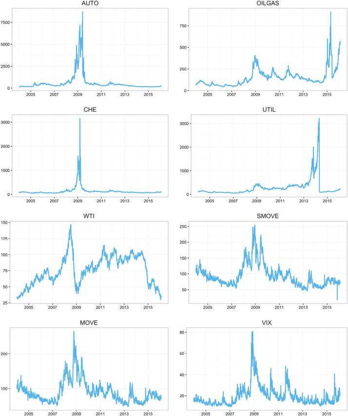

Fig. 1. Time-series plots of level of the [CDS](https://www.sciencedirect.com/topics/economics-econometrics-and-finance/credit-derivative) premium, oil price, and volatility indices.

Fig. 2 shows the estimated conditional correlations obtained from the BEKK-GARCH model with a Student's t distribution. All eight variables that we use in our study show signs of volatility clustering. They all have upwards and downwards during the time depending on the different shocks. As can be observed from Fig. 2, conditional correlation between MOVE and SMOVE is generally close to 1 during the chosen time period and volatility is very low compared to other conditional correlations, which can be expected owing to high interdependency between these two risk measures as observed in Table 1 and Fig. 1.

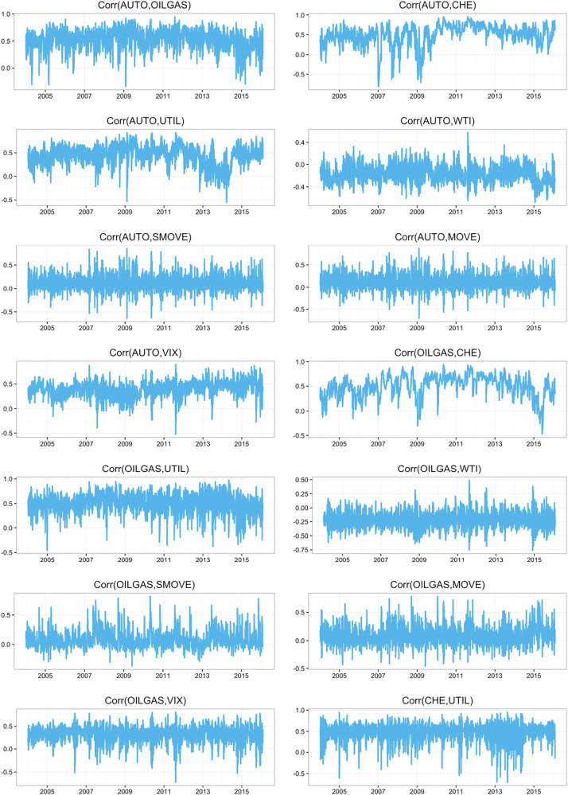

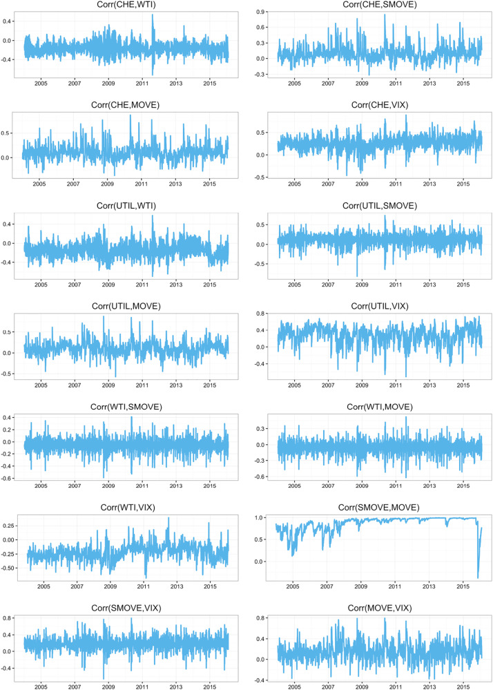

Fig. 2. Conditional correlations from the BEKK-GARCH model.

Highest volatility can be seen between AUTO-CHE in 2007 and 2009, and between CHE-UTIL in 2013. Therefore, it can be concluded that high volatilities of AUTO-CHE and CHE-UTIL are due to different shocks, i.e. they have low interdependency. On the other hand, lowest volatilities are observed between WTI-SMOVE/MOVE and WTI-VIX, considering the peak-to-valley differences of the conditional correlations.

General conditional correlation trend between four CDS Premiums are positive and their profiles suggest volatility between these measures. Conditional correlations between AUTO and the other CDS Premiums (CHE, OILGAS and UTIL) have high downward peak around 2009, which can be correlated with Lehman Brothers bankruptcy shock. However, same trend between each four CDS Premiums and WTI are negative but close to zero whereas the trend between each four CDS Premiums and VIX is positive, except the steep upwards and downwards due to different responses of the risk measures against different shocks. Conditional correlations between each four CDS Premiums and MOVE/SMOVE are generally close to zero except the responses against the shocks encountered during the time period. Slight positive conditional correlation can be observed between MOVE/SMOVE and VIX having similar volatility levels.

## 4. Methodology of VIRF

### 4.1. Independent shocks

In this section, we define our model used to examine the risk spillover mechanism across the oil market, financial market, and the oil related CDS sectors. In addition to showing the magnitude of the volatility transmission, we describe the methodology of the volatility impulse responses. This method has the advantage of providing valuable information on the speed of risk transmission, as well as the shape and sign of the volatility impulse responses also provide significant information.

News or shocks are inherently independent over time as introduced as a new concept by Hafner and Herwartz (2006). A shock is a risk source that is independent and unpredictable. It is also shown that two shocks appearing in different series at the same time are independent. The residuals include the effects of the shocks coming from independent sources. However, in order to obtain the pure impact of the shock, the orthogonality conditions of the error terms should be investigated. Otherwise, total effect of one shock on all the components of the residual will be observed. In order to avoid orthogonality problem, Hafner and Herwartz (2006) will be applied Jordan decomposition to retrieve an independent and realistic shock from the conditionally heteroskedastic error terms.

The component of our model that shows the effect of a shock is named as *z*<sub>*t*</sub> in *ε*<sub>*t*</sub> by Choleski decomposition. Independent news could be identified via Jordan decomposition of *H*<sub>*t*</sub>. Let Λ<sub>it</sub> = diag (λ<sub>1t</sub>, …, λ<sub>Nt</sub>) is the diagonal matrix whose components λ<sub>it</sub>, *i* = 1, …, *N* denote the eigenvalues of *H*<sub>*t*</sub>. Γ<sub>*it*</sub> = (*γ*<sub>1*t*</sub>, …, *γ*<sub>*Nt*</sub>) is the matrix N*N whose components Γ<sub>*it*</sub>, *i* = 1, …, *N* denote the corresponding eigenvectors. The symmetric matrix of $Ht1/2$ can be decomposed as;(4)$Ht1/2=ΓtΛt1/2Γt′$

As Hafner and Herwartz (2006) identifies *z*<sub>*t*</sub> as shocks from the past that are able to affect the markets in the future. Therefore, the independent shocks are defined as;(5)$zt=Ht−1/2εt$

### 4.2. Volatility impulse response function (VIRF)

According to Bollerslev et al. (1988) the BEKK (1,1) model for multivariate GARCH models can be written by using Vector Error Correction (VEC) model representation as follows:(6)$vechHt=vechC+Avechεt−1εt−1′+BvechHt−1$in which *H*<sub>*t*</sub> is the conditional covariance matrix at time *t* and *vech*(*H*<sub>*t*</sub>) indicates the operator that stacks the lower fraction of an 8*8 matrix into an N* = (N(N + 1)/2) dimensional vector. *vech*(*C*) is a vector which contains N* coefficients, *A* and *B* are the parameter matrices containing (N*)<sup>2</sup> parameters. This VEC model is used to eliminate the variables of the conditional covariance matrix that appear twice in the model.

According to Hafner and Herwartz (2006), VIRF is the expectation of volatility conditional on an initial shock and history subtracted by the baseline expectation that only conditional on history, which can be written as follows;(7)$Vhzt=EvechHtψt−1,zt−EvechHtψt−1$where *z*<sub>*t*</sub> is the specific shock affecting the system at time *t* and *ψ*<sub>*t*−1</sub> is the observed history up to time *t* − 1. *V*<sub>*h*</sub>(*z*<sub>*t*</sub>) is the N* = (N (N + 1)/2) vector of the impact of the identical and independent shock components of *z*<sub>*t*</sub> on the h-step ahead expected conditional variance-covariance matrix components. Therefore, to find the Eq. (7), the expectation matrix influenced by only history is subtracted from the h-step ahead expected conditional covariance matrix of a given shock and history. As a result, the model of *V*<sub>*h*</sub>(*z*<sub>*t*</sub>) shows the reaction of the conditional variance of the eight variables respectively to the shock, *z*<sub>*t*</sub> that occurred *h* period ago. One-step ahead VIRF applied to a BEKK (1,1) model is,(8)$V1zt=AvechHt1/2ztzt′Ht1/2−vechHt=ADN+Ht1/2⊗Ht1/2DNvechztzt′−IN$where *D*<sub>*N*</sub> is the duplication matrix defined from the property as:(9)$vechZ=DNvechZ$for any symmetric N*N matrix *Z* and *D*<sub>*N*</sub><sup>+</sup> is its Moore-Penrose inverse. *I*<sub>*N*</sub> is the identity matrix and *H*<sub>*t*</sub> is the conditional variance-covariance matrix representation at time *t*. ⊗ represents the Kronecker product. For h > 1, the new VIRF is;(10)$Vhzt=A+Bh−1ADN+Ht1/2⊗Ht1/2DNvechztzt′−IN=A+BVh−1zt$

Compared to the traditional Choleski decomposition impulse response function of the conditional mean in linear models, VIRF model defined by Hafner and Herwartz (2006) has the following important properties:

- 1)

  The VIRF is an even, symmetric function of the shock with the property of *V*<sub>*h*</sub>(*z*<sub>*t*</sub>) = *V*<sub>*h*</sub>(−*z*<sub>*t*</sub>). The impulse responses are odd functions in traditional linear analysis.
- 2)

  The VIRF is not homogenous function of any degree while the traditional linear analyses are.
- 3)

  The VIRF depends on the history through the volatility state *H*<sub>*t*</sub> at the time of the initial shock occurs. However, the traditional analysis on linear systems does not depend on the historic shocks.
- 4)

  The persistence of shocks is calculated in moving average part same in the traditional, (*A* + *B*)<sup>*h*−1</sup> *A*.

In our study, *z*<sub>*t*</sub> is chosen as a shock with an independent and identically distributed random variable. The impact of a historical random shock is calculated by the observed volatility when a shock occurs. However, we are interested in the past events that have an impact on today and future. In the next part, the impact of observed historical shocks with observed volatilities will give information about past events.

## 5. Empirical results

This chapter contains the results of the impacts of historical shocks on volatilities. In the sample period, several shocks and effects are witnessed owing to our VIRF analysis. We focus on specific historical shocks: the US [mortgage](https://www.sciencedirect.com/topics/economics-econometrics-and-finance/mortgages) crisis: Lehman Brothers bankruptcy, Greece debt crisis, fear of Greece's default, Egyptian political unrest (Second Revolution), European sovereign debt crisis and US government shutdown that have significant effects on our variables. According to our best knowledge, the impacts of the listed six shocks within and across the oil related markets and financial market risks have not been considered in VIRF analyses in the literature.

Fig. 3 reports the responses of shocks as impulse response to covariances of eight variables used in this study. Nonzero positive impulse responses imply risk transmission. We note that some of the shocks might be negative at the date of shock and the impulse response might be negative. However, negative impulse responses still imply risk transmission. This is due to the fact that the shocks are not normalized in terms of the sign and the size.

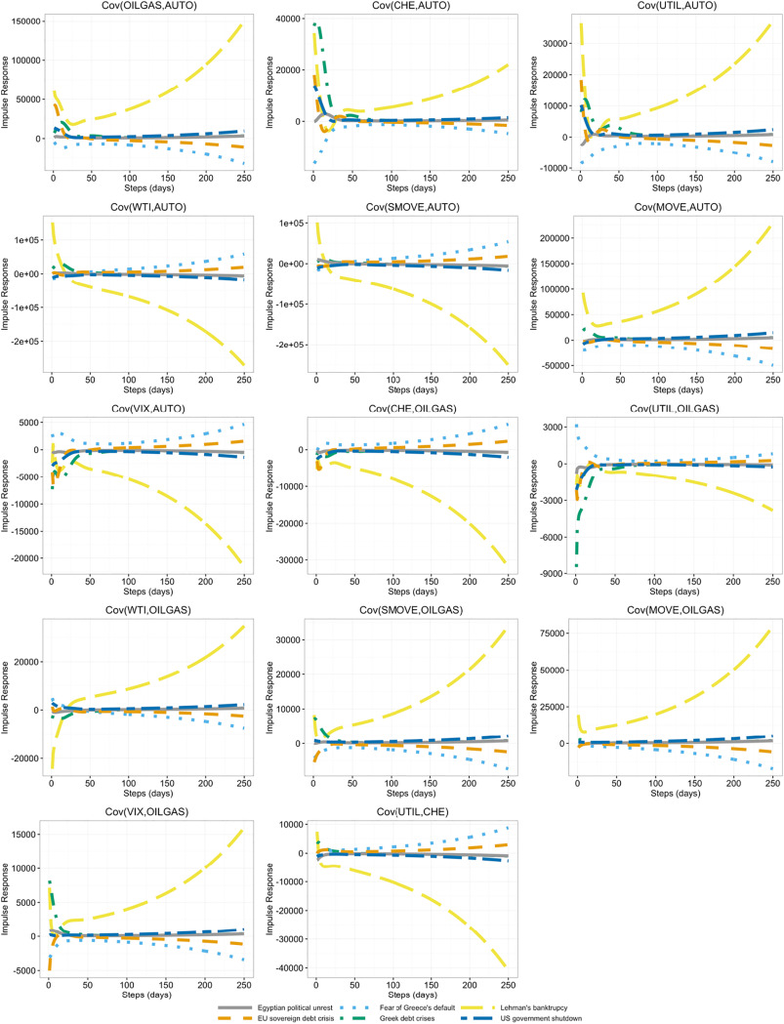

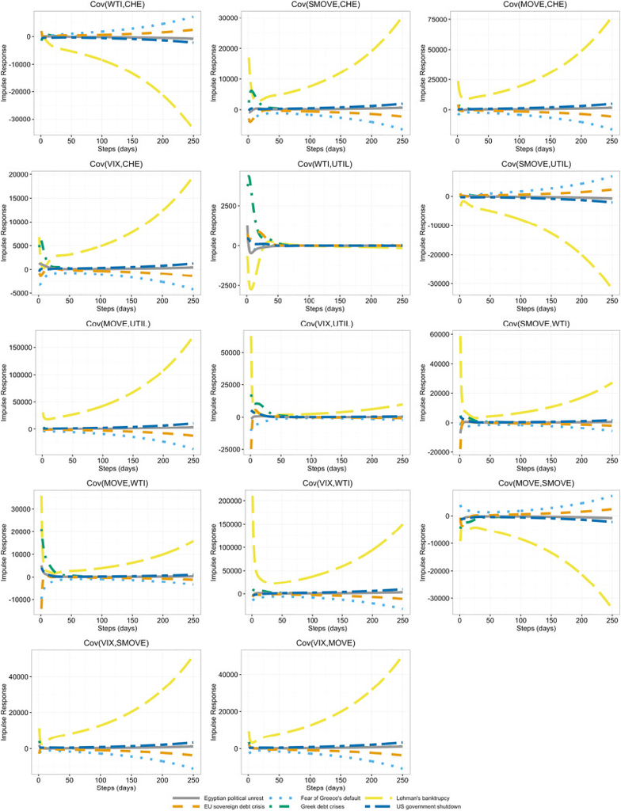

Fig. 3. Responses of covariances to various shocks.

Note: The figure reports the response of the covariances to the shock due to following events: Lehman Brothers bankruptcy on Sep 17, 2008; Greece debt crises on Dec 8, 2009; Fear of Greece's default on April 23, 2010; Egyptian political unrest (Second Revolution) on May 27, 2011; European sovereign debt crisis on August 18, 2011; and US government shutdown on Sept 30, 2013.

### 5.1. US mortgage crisis: Lehman Brothers bankruptcy on 17 September 2008

Lehman Brothers, one of the [financial services](https://www.sciencedirect.com/topics/economics-econometrics-and-finance/financial-services) firms in US, declared bankruptcy on 15 September 2008. This is the largest bankruptcy announcement in US history. The main reason for the bankruptcy can be associated with large decline of home prices after the collapse in mortgage market. The starting point of US mortgage crisis is accepted as the announcement of the bankruptcy of Lehman Brothers. This event influenced all the markets significantly not in the US but also worldwide. In our analysis, 17 September 2008 is accepted as the base point and we investigate the effects of this event, named also as shock, on our risk transmission and correlation analysis after this date.

As can be seen in Fig. 3, significant but various types of responses are observed for all the covariances due to Lehman Brothers bankruptcy. This event or shock has the highest influence on the reported covariances compared to other five events. Since all the variables used in this study are US-based, higher influence of Lehman Brothers bankruptcy to response of covariances can be expected.

Our findings are similar to Narayan (2015), as in this study it was also found that while CDS shocks explained most of the forecast error variance of the sectoral [equity returns](https://www.sciencedirect.com/topics/economics-econometrics-and-finance/capital-market-returns) over the crisis period, the effect was the mostly dominated during the post-Lehman crisis period. Hammoudeh et al. (2013) also prove the local impact of financial crisis to the specific US sectors.

Covariances of VIX-AUTO, CHE-OILGAS, UTIL-OILGAS, WTI-CHE, SMOVE-UTIL and MOVE-SMOVE have negative responses to Lehman Brothers bankruptcy shock and negative responses tend to be higher in the long run. Covariances of WTI-AUTO, SMOVE-AUTO and UTIL-CHE shift their response from positive to negative whereas the change of covariance of WTI-OILGAS is vice-versa. The change in response occurs after a very short time from Lehman Brothers bankruptcy. The rest of the covariances show positive response to this shock, however, their profiles are different. In addition, right after the shock, the covariances have slight positive response, which tend to become zero in the short run and have increase in the long run except CHE-AUTO, UTIL-AUTO, VIX-UTIL, SMOVE-WTI, MOVE-WTI and VIX-WTI.

### 5.2. Greece debt crisis on 8 December 2009 and fear of Greece's default on 23 April 2010

Greece was accepted to the European Union on 1 January 1981. Gross domestic product (GDP) per capita reached the highest values in 2008, as around $31,700 after adapting to the currency of Euro in 2001. The second shock we select is “Greece debt crisis” started officially on 8 December 2009 when country's credit rating was downgraded by Fitch from A− to BBB+. On 4 March 2010; government announced [austerity](https://www.sciencedirect.com/topics/economics-econometrics-and-finance/fiscal-consolidation) plan. On 23 April 2010, third shock in our analysis, “fear of Greece's default” is assumed to be started after George Papandreou, the Prime Minister of that time, called for an EU/IMF rescue package of €500 bn for 3 years. This rescue package was not enough and second Greek crisis began because of Greek budget deficit was declared as higher than expected in April 2011. After that, credit rating of Greece was decreased from B to CCC. Second bailout loan was confirmed for €130 bn. Therefore, interest rate increased and bond prices decreased. Banks and Greek Stock Exchange Market closed for a month in June 2015. Unemployment rate rose to 24.5% in November 2015. As a result, confidence in Government services was at a low point.

### 5.3. Egyptian political unrest (Second Revolution) on 27 May 2011

In Egypt, thousands of people protested for the step down of Husni Mubarak, the President for 30 years, and for changing the regime to democracy. Police used violence to stop protestors on the streets resulting injuries and deaths. First revolution of Egypt named as the Arab Spring was placed on 25 January 2011. Muslim Brotherhood was a large crowd of [faces](https://www.sciencedirect.com/topics/agricultural-and-biological-sciences/face) of the protests. Demonstrators filled Gharbeya, Alexandria, Suez, Ismailia and also Tahrir Square in Cairo on 27 May 2011, which was accepted as the base point in our analysis. The demands of the crowd were for civilians not to be judged in military trials, all members of the Mubarak regime and those who killed protestors to be put on trial. And before parliament elections, demonstrators wanted the restoration of the Egyptian Constitution.

### 5.4. European sovereign debt crisis on 18 August 2011

European sovereign debt crisis started at the end of 2009 around European Union because of having difficulties in refinancing government debts or repayments of loans to Eurozone countries, [European Central Bank](https://www.sciencedirect.com/topics/economics-econometrics-and-finance/european-central-bank) (ECB) and International Monetary Fund (IMF). Increase in [government expenditures](https://www.sciencedirect.com/topics/economics-econometrics-and-finance/government-expenditure) and investments, troubles in housing market therefore in banking system, small economic growth and also low productivity were main reasons for crisis especially around these Eurozone member countries; i.e. Greece, Portugal, Ireland, Spain and Cyprus. The impress of sovereign debt crisis was not only on the entire Eurozone but also on European Union countries and worldwide.

The transmission process between different sectors in financial markets through which the crisis had spread were studied by Chudik and Fratzscher (2011). The results demonstrated that the global transmission of the crisis was complex and could not be reduced to a single dimension.

European sovereign debt crisis has slight effect on covariances in the short-run, which tends to become zero in the medium term. However, the responses of the covariances of the risk measures slightly change as time passes. As can be seen in Fig. 3, the highest response to this shock is observed for OILGAS-AUTO covariance. After an initial positive response, it decreases to 0 in a very short time and becomes slightly negative. Considering the rest of the covariances, after an initial shock, the response approaches to zero and becomes either positive or negative in the long run. Another remarkable feature is that covariances tend to show higher response to fear of Greece's default compared to European sovereign debt crisis in the long term.

### 5.5. US government shutdown on 30 September 2013

The two chambers of US Congress could not be agreed on the offer of increasing the federal government's debt ceiling or called extra fund to finance Patient Protection and Affordable Care Act known as Obamacare signed in 2010. As a result, US government was shut down on 1 October until 16 October 2013. Non-compulsory expenditures were stopped and government postponed payments. Approximately 800,000 federal employees were forced for an unpaid leave. This event influenced financial agents and markets negatively, as can be expected. The base shock date chosen for our analyses is a day ago from the beginning of shutdown.

## 6. Conclusion

This study examines the volatility transmission mechanism across the oil and financial markets and sector CDSs, using eight different measures of risks during the period 6 January 2004–2 February 2016. In addition to assessing the magnitude of the volatility transmission, the volatility impulse responses have the advantage of providing valuable information on the speed of risk transmission. The shape and sign of the volatility impulse responses also provide significant information on the transmission mechanism. We also evaluate the risk transmission due to global shocks related to the US mortgage crisis: Lehman Brothers bankruptcy, Greece debt crisis, fear of Greece's default, Egyptian political unrest (Second Revolution), European sovereign debt crisis and US government shutdown and observe that most of these events lead to significant risk transmission. Among these events, the Lehman Brothers bankruptcy has destabilizing effects on all the oil-related sectors. We also find that all oil market related shocks have significant risk transmission effects. Finally, the results show complicated transmission mechanisms that spread over long periods.

## Appendix A. Supplementary data

[Download: Download zip file (366KB)](https://ars.els-cdn.com/content/image/1-s2.0-S0140988318302779-mmc1.zip)

Supplementary material

## References

1. Adams et al., 2015

   Z. Adams, R. Füss, F. Schindler

   The sources of risk spillovers among U.S. REITs: financial characteristics and regional proximity

   Real Estate Econ., 43 (2015), pp. 67-100

   [Crossref](https://doi.org/10.1111/1540-6229.12060)[View in Scopus](https://www.scopus.com/inward/record.url?eid=2-s2.0-84923034545&partnerID=10&rel=R3.0.0)Google Scholar
2. Alexander and Kaeck, 2008

   C. Alexander, A. Kaeck

   Regime dependent determinants of credit default swap spreads

   J. Bank. Financ., 32 (2008), pp. 1008-1021

   [View PDF](https://www.sciencedirect.com/science/article/pii/S0378426607002877/pdfft?md5=f5014a61eee0982e977329c2bc08ae7e&pid=1-s2.0-S0378426607002877-main.pdf)[View article](https://www.sciencedirect.com/science/article/pii/S0378426607002877)[View in Scopus](https://www.scopus.com/inward/record.url?eid=2-s2.0-43049164025&partnerID=10&rel=R3.0.0)[Google Scholar](https://scholar.google.com/scholar_lookup?title=Regime%20dependent%20determinants%20of%20credit%20default%20swap%20spreads&publication_year=2008&author=C.%20Alexander&author=A.%20Kaeck)
3. Annaert et al., 2013

   J. Annaert, M. De Ceuster, P. Van Roy, C. Vespro

   What determines Euro area bank CDS spreads?

   J. Int. Money Financ., 32 (2013), pp. 444-461

   [View PDF](https://www.sciencedirect.com/science/article/pii/S0261560612001386/pdfft?md5=49524b6a3f516b9c7c236b5c71b163a7&pid=1-s2.0-S0261560612001386-main.pdf)[View article](https://www.sciencedirect.com/science/article/pii/S0261560612001386)[View in Scopus](https://www.scopus.com/inward/record.url?eid=2-s2.0-84874788068&partnerID=10&rel=R3.0.0)Google Scholar
4. Arouri et al., 2014

   M. Arouri, S. Hammoudeh, F. Jawadi, D.K. Nguyen

   Financial linkages between US sector credit default swaps markets

   J. Int. Financ. Mark. Inst. Money, 33 (2014), pp. 223-243

   [View PDF](https://www.sciencedirect.com/science/article/pii/S1042443114001061/pdfft?md5=8feced04ae2cf6cab5afda4f87bbc48a&pid=1-s2.0-S1042443114001061-main.pdf)[View article](https://www.sciencedirect.com/science/article/pii/S1042443114001061)[View in Scopus](https://www.scopus.com/inward/record.url?eid=2-s2.0-84907880190&partnerID=10&rel=R3.0.0)Google Scholar
5. Beaudry and Koop, 1993

   P. Beaudry, G. Koop

   Do recessions permanently change output?

   J. Monet. Econ., 31 (1993), pp. 149-163

   [View PDF](https://www.sciencedirect.com/science/article/pii/030439329390042E/pdf?md5=6b4d00757ffa06d9d5956258148d51db&pid=1-s2.0-030439329390042E-main.pdf)[View article](https://www.sciencedirect.com/science/article/pii/030439329390042E)[View in Scopus](https://www.scopus.com/inward/record.url?eid=2-s2.0-0001289268&partnerID=10&rel=R3.0.0)[Google Scholar](https://scholar.google.com/scholar_lookup?title=Do%20recessions%20permanently%20change%20output&publication_year=1993&author=P.%20Beaudry&author=G.%20Koop)
6. Becker et al., 1990

   K.G. Becker, J.E. Finnerty, M. Gupta

   The intertemporal relation between the U. S. and Japanese stock markets

   J. Financ., 45 (1990), pp. 1297-1306

   [View in Scopus](https://www.scopus.com/inward/record.url?eid=2-s2.0-84977734114&partnerID=10&rel=R3.0.0)Google Scholar
7. Becker et al., 2009

   R. Becker, A.E. Clements, A. McClelland

   The jump component of S&P 500 volatility and the VIX index

   J. Bank. Financ., 33 (2009), pp. 1033-1038

   [View PDF](https://www.sciencedirect.com/science/article/pii/S0378426608002653/pdfft?md5=6da2a5df4c39536dbfe699629e635715&pid=1-s2.0-S0378426608002653-main.pdf)[View article](https://www.sciencedirect.com/science/article/pii/S0378426608002653)[View in Scopus](https://www.scopus.com/inward/record.url?eid=2-s2.0-62749177967&partnerID=10&rel=R3.0.0)Google Scholar
8. Berndt et al., 2008

   A. Berndt, R. Douglas, D. Duffie, M. Ferguson, D. Schranz

   Measuring Default Risk Premia From Default Swap Rates and EDFs. BIS Working Paper No. 173; EFA 2004 Maastricht Meetings Paper No. 5121

   (Available at SSRN)

   http://ssrn.com/abstract=556080 (2008)

   Google Scholar
9. Bharath and Shumway, 2004

   S.T. Bharath, T. Shumway

   Forecasting Default With the KMV-Merton Model

   (Available at SSRN)

   http://ssrn.com/abstract=637342 (2004)

   [Google Scholar](https://scholar.google.com/scholar_lookup?title=Forecasting%20Default%20With%20the%20KMV-Merton%20Model&publication_year=2004&author=S.T.%20Bharath&author=T.%20Shumway)
10. Blanchard and Quah, 1989

    O.J. Blanchard, D. Quah

    The dynamic effects of aggregate demand and supply disturbances

    Am. Econ. Rev., 79 (1989), pp. 655-673

    [View in Scopus](https://www.scopus.com/inward/record.url?eid=2-s2.0-85016078433&partnerID=10&rel=R3.0.0)[Google Scholar](https://scholar.google.com/scholar_lookup?title=The%20dynamic%20effects%20of%20aggregate%20demand%20and%20supply%20disturbances&publication_year=1989&author=O.J.%20Blanchard&author=D.%20Quah)
11. Bollerslev et al., 1988

    T. Bollerslev, R. Engle, J. Wooldridge

    A capital asset pricing model with time-varying covariances

    J. Polit. Econ., 96 (1988), pp. 116-131

    [Google Scholar](https://scholar.google.com/scholar_lookup?title=A%20capital%20asset%20pricing%20model%20with%20time-varying%20covariances&publication_year=1988&author=T.%20Bollerslev&author=R.%20Engle&author=J.%20Wooldridge)
12. Booth et al., 1997

    G.G. Booth, M. Chowdhury, T. Martikainen, Y. Tse

    Intraday volatility in International stock index futures markets: meteor showers or heat waves?

    Manag. Sci., 43 (1997), pp. 1564-1576

    [Crossref](https://doi.org/10.1287/mnsc.43.11.1564)[View in Scopus](https://www.scopus.com/inward/record.url?eid=2-s2.0-0031268642&partnerID=10&rel=R3.0.0)Google Scholar
13. Byström, 2006

    H. Byström

    Credit default swaps and equity prices: the iTraxx CDS index market

    Financ. Anal. J., 62 (2006), pp. 65-76

    [Crossref](https://doi.org/10.2469/faj.v62.n6.4354)[Google Scholar](https://scholar.google.com/scholar_lookup?title=Credit%20default%20swaps%20and%20equity%20prices%3A%20the%20iTraxx%20CDS%20index%20market&publication_year=2006&author=H.%20Bystr%C3%B6m)
14. Chan and Marsden, 2014

    K.F. Chan, A. Marsden

    Macro risk factors of credit default swap indices in a regime-switching framework

    J. Int. Financ. Mark. Inst. Money, 29 (2014), pp. 285-308

    [View PDF](https://www.sciencedirect.com/science/article/pii/S1042443114000031/pdfft?md5=ecec2aac254a2cdc781f307656a9dcbc&pid=1-s2.0-S1042443114000031-main.pdf)[View article](https://www.sciencedirect.com/science/article/pii/S1042443114000031)[View in Scopus](https://www.scopus.com/inward/record.url?eid=2-s2.0-84893430559&partnerID=10&rel=R3.0.0)Google Scholar
15. Chudik and Fratzscher, 2011

    A. Chudik, M. Fratzscher

    Identifying the global transmission of the 2007–2009 financial crisis in a GVAR model

    Eur. Econ. Rev., 55 (2011), pp. 325-339

    [View PDF](https://www.sciencedirect.com/science/article/pii/S001429211000125X/pdfft?md5=d91ded5abfcd0c35a8c8b423004917f7&pid=1-s2.0-S001429211000125X-main.pdf)[View article](https://www.sciencedirect.com/science/article/pii/S001429211000125X)[View in Scopus](https://www.scopus.com/inward/record.url?eid=2-s2.0-79952192645&partnerID=10&rel=R3.0.0)Google Scholar
16. Cremers et al., 2008

    K.J.M. Cremers, J. Driessen, P. Maenhout

    Explaining the level of credit spreads: option-Implied jump risk premia in a firm value model

    Rev. Financ. Stud., 21 (2008), pp. 2209-2242

    [Crossref](https://doi.org/10.1093/rfs/hhn071)[View in Scopus](https://www.scopus.com/inward/record.url?eid=2-s2.0-52649119776&partnerID=10&rel=R3.0.0)Google Scholar
17. Da Fonseca and Ignatieva, 2018

    J. Da Fonseca, K. Ignatieva

    Volatility spillovers and connectedness among credit default swap sector indexes

    Appl. Econ. (2018), pp. 1-14

    [Crossref](https://doi.org/10.7213/1981-4178.2018.16010)Google Scholar
18. Das and Hanouna, 2006

    S.R. Das, P. Hanouna

    Credit default swap spreads

    J. Invest. Manag., 4 (2006), pp. 93-105

    [View in Scopus](https://www.scopus.com/inward/record.url?eid=2-s2.0-34548727593&partnerID=10&rel=R3.0.0)[Google Scholar](https://scholar.google.com/scholar_lookup?title=Credit%20default%20swap%20spreads&publication_year=2006&author=S.R.%20Das&author=P.%20Hanouna)
19. Diebold and Yilmaz, 2009

    F.X. Diebold, K. Yilmaz

    Measuring financial asset return and volatility spillovers, with application to global equity markets*

    Econ. J., 119 (2009), pp. 158-171

    [Crossref](https://doi.org/10.1111/j.1468-0297.2008.02208.x)[View in Scopus](https://www.scopus.com/inward/record.url?eid=2-s2.0-57749109009&partnerID=10&rel=R3.0.0)Google Scholar
20. Doan et al., 1983

    T. Doan, R.B. Litterman, C.A. Sims

    Forecasting and Conditional Projection Using Realistic Prior Distributions. National Bureau of Economic Research Working Paper Series

    (1983)

    (No. 1202)

    Google Scholar
21. Engle and Kroner, 1995

    R.F. Engle, K.F. Kroner

    Multivariate simultaneous generalized Arch

    Economet. Theor., 11 (1995), pp. 122-150

    [View in Scopus](https://www.scopus.com/inward/record.url?eid=2-s2.0-84974122247&partnerID=10&rel=R3.0.0)[Google Scholar](https://scholar.google.com/scholar_lookup?title=Multivariate%20simultaneous%20generalized%20Arch&publication_year=1995&author=R.F.%20Engle&author=K.F.%20Kroner)
22. Engle and Ng, 1993

    R.F. Engle, V.K. Ng

    Measuring and testing the impact of news on volatility

    J. Financ., 48 (1993), pp. 1749-1778

    [Google Scholar](https://scholar.google.com/scholar_lookup?title=Measuring%20and%20testing%20the%20impact%20of%20news%20on%20volatility&publication_year=1993&author=R.F.%20Engle&author=V.K.%20Ng)
23. Engle et al., 1990

    R.F. Engle, T. Ito, W.-L. Lin

    Meteor showers or heat waves? Heteroskedastic intra-daily volatility in the foreign exchange market

    Econometrica, 58 (1990), pp. 525-542

    [Crossref](https://doi.org/10.2307/2938189)Google Scholar
24. Ericsson et al., 2009

    J. Ericsson, K. Jacobs, R. Oviedo

    The determinants of credit default swap premia

    J. Financ. Quant. Anal., 44 (2009), pp. 109-132

    [View in Scopus](https://www.scopus.com/inward/record.url?eid=2-s2.0-67649643503&partnerID=10&rel=R3.0.0)[Google Scholar](https://scholar.google.com/scholar_lookup?title=The%20determinants%20of%20credit%20default%20swap%20premia&publication_year=2009&author=J.%20Ericsson&author=K.%20Jacobs&author=R.%20Oviedo)
25. Eun and Shim, 1989

    C.S. Eun, S. Shim

    International transmission of stock market movements

    J. Financ. Quant. Anal., 24 (1989), pp. 241-256

    [Crossref](https://doi.org/10.2307/2330774)[View in Scopus](https://www.scopus.com/inward/record.url?eid=2-s2.0-84974489613&partnerID=10&rel=R3.0.0)[Google Scholar](https://scholar.google.com/scholar_lookup?title=International%20transmission%20of%20stock%20market%20movements&publication_year=1989&author=C.S.%20Eun&author=S.%20Shim)
26. Ewing et al., 2002

    B.T. Ewing, F. Malik, O. Ozfidan

    Volatility transmission in the oil and natural gas markets

    Energy Econ., 24 (2002), pp. 525-538

    [View PDF](https://www.sciencedirect.com/science/article/pii/S0140988302000609/pdfft?md5=fb14b3c9a3fd06dfa6b38fd913e2a126&pid=1-s2.0-S0140988302000609-main.pdf)[View article](https://www.sciencedirect.com/science/article/pii/S0140988302000609)[View in Scopus](https://www.scopus.com/inward/record.url?eid=2-s2.0-0036852496&partnerID=10&rel=R3.0.0)[Google Scholar](https://scholar.google.com/scholar_lookup?title=Volatility%20transmission%20in%20the%20oil%20and%20natural%20gas%20markets&publication_year=2002&author=B.T.%20Ewing&author=F.%20Malik&author=O.%20Ozfidan)
27. Fernandes et al., 2014

    M. Fernandes, M.C. Medeiros, M. Scharth

    Modeling and predicting the CBOE market volatility index

    J. Bank. Financ., 40 (2014), pp. 1-10

    [View PDF](https://www.sciencedirect.com/science/article/pii/S0378426613004172/pdfft?md5=96295a1d21332bb3c105c39017b4f0bc&pid=1-s2.0-S0378426613004172-main.pdf)[View article](https://www.sciencedirect.com/science/article/pii/S0378426613004172)[Crossref](https://doi.org/10.1155/2014/382891)[Google Scholar](https://scholar.google.com/scholar_lookup?title=Modeling%20and%20predicting%20the%20CBOE%20market%20volatility%20index&publication_year=2014&author=M.%20Fernandes&author=M.C.%20Medeiros&author=M.%20Scharth)
28. Figuerola-Ferretti and Paraskevopoulos, 2011

    I. Figuerola-Ferretti, I. Paraskevopoulos

    Pairing Market Risk With Credit Risk

    Universidad Carlos III, Departamento de Economía de la Empresa (2011)

    [Google Scholar](https://scholar.google.com/scholar_lookup?title=Pairing%20Market%20Risk%20With%20Credit%20Risk&publication_year=2011&author=I.%20Figuerola-Ferretti&author=I.%20Paraskevopoulos)
29. Forte and Lovreta, 2008

    S. Forte, L. Lovreta

    Credit Risk Discovery in the Stock and CDS Markets: Who Leads, When, and Why

    (Available at SSRN)

    http://ssrn.com/abstract=1183202 (2008)

    Google Scholar
30. Forte and Peña, 2009

    S. Forte, J.I. Peña

    Credit spreads: an empirical analysis on the informational content of stocks, bonds, and CDS

    J. Bank. Financ., 33 (2009), pp. 2013-2025

    [View PDF](https://www.sciencedirect.com/science/article/pii/S037842660900096X/pdfft?md5=1995812fb821972792925122ac4579fc&pid=1-s2.0-S037842660900096X-main.pdf)[View article](https://www.sciencedirect.com/science/article/pii/S037842660900096X)[View in Scopus](https://www.scopus.com/inward/record.url?eid=2-s2.0-70249121398&partnerID=10&rel=R3.0.0)Google Scholar
31. Fung et al., 2008

    H.-G. Fung, G.E. Sierra, J. Yau, G. Zhang

    Are the U.S. stock market and credit default swap market related? Evidence from the CDX indices

    J. Altern. Invest., 11 (2008), pp. 43-61

    [Crossref](https://doi.org/10.3905/jai.2008.708849)[View in Scopus](https://www.scopus.com/inward/record.url?eid=2-s2.0-48749099111&partnerID=10&rel=R3.0.0)Google Scholar
32. Galil et al., 2014

    K. Galil, O.M. Shapir, D. Amiram, U. Ben-Zion

    The determinants of CDS spreads

    J. Bank. Financ., 41 (2014), pp. 271-282

    [View PDF](https://www.sciencedirect.com/science/article/pii/S0378426613004676/pdfft?md5=0383e532813fa687ca62fbf7583e290e&pid=1-s2.0-S0378426613004676-main.pdf)[View article](https://www.sciencedirect.com/science/article/pii/S0378426613004676)[View in Scopus](https://www.scopus.com/inward/record.url?eid=2-s2.0-84894231255&partnerID=10&rel=R3.0.0)[Google Scholar](https://scholar.google.com/scholar_lookup?title=The%20determinants%20of%20CDS%20spreads&publication_year=2014&author=K.%20Galil&author=O.M.%20Shapir&author=D.%20Amiram&author=U.%20Ben-Zion)
33. Gallant et al., 1993

    A. Gallant, P. Rossi, G. Tauchen

    Nonlinear dynamic structures

    Econometrica, 61 (1993), pp. 871-907

    [Crossref](https://doi.org/10.2307/2951766)[Google Scholar](https://scholar.google.com/scholar_lookup?title=Nonlinear%20dynamic%20structures&publication_year=1993&author=A.%20Gallant&author=P.%20Rossi&author=G.%20Tauchen)
34. Grobys, 2010

    K. Grobys

    Have volatility spillover effects of cointegrated European stock markets increased over time?

    Rev. Financ. Bank., 02 (2010), pp. 83-94

    [Google Scholar](https://scholar.google.com/scholar_lookup?title=Have%20volatility%20spillover%20effects%20of%20cointegrated%20European%20stock%20markets%20increased%20over%20time&publication_year=2010&author=K.%20Grobys)
35. Guo et al., 2011

    F. Guo, C.R. Chen, Y.S. Huang

    Markets contagion during financial crisis: a regime-switching approach

    Int. Rev. Econ. Financ., 20 (2011), pp. 95-109

    [View PDF](https://www.sciencedirect.com/science/article/pii/S1059056010000523/pdfft?md5=7ec5e469ac10bcf1b734f281103184a7&pid=1-s2.0-S1059056010000523-main.pdf)[View article](https://www.sciencedirect.com/science/article/pii/S1059056010000523)[View in Scopus](https://www.scopus.com/inward/record.url?eid=2-s2.0-78049474160&partnerID=10&rel=R3.0.0)Google Scholar
36. Hafner and Herwartz, 2006

    C.M. Hafner, H. Herwartz

    Volatility impulse responses for multivariate GARCH models: an exchange rate illustration

    J. Int. Money Financ., 25 (2006), pp. 719-740

    [View PDF](https://www.sciencedirect.com/science/article/pii/S0261560606000362/pdfft?md5=ab35c2ac44c391f79b6a6189c39cd4e4&pid=1-s2.0-S0261560606000362-main.pdf)[View article](https://www.sciencedirect.com/science/article/pii/S0261560606000362)[View in Scopus](https://www.scopus.com/inward/record.url?eid=2-s2.0-33748434064&partnerID=10&rel=R3.0.0)Google Scholar
37. Hamao et al., 1990

    Y. Hamao, R.W. Masulis, V. Ng

    Correlations in price changes and volatility across international stock markets

    Rev. Financ. Stud., 3 (1990), pp. 281-307

    Google Scholar
38. Hammoudeh et al., 2013

    S. Hammoudeh, T. Liu, C.-L. Chang, M. McAleer

    Risk spillovers in oil-related CDS, stock and credit markets

    Energy Econ., 36 (2013), pp. 526-535

    [View PDF](https://www.sciencedirect.com/science/article/pii/S0140988312002599/pdfft?md5=ce3fe0dcf0b54e76360b10cbd01a28e4&pid=1-s2.0-S0140988312002599-main.pdf)[View article](https://www.sciencedirect.com/science/article/pii/S0140988312002599)[View in Scopus](https://www.scopus.com/inward/record.url?eid=2-s2.0-84874307014&partnerID=10&rel=R3.0.0)Google Scholar
39. Jarque and Bera, 1980

    C.M. Jarque, A.K. Bera

    Efficient tests for normality, homoscedasticity and serial independence of regression residuals

    Econ. Lett., 6 (1980), pp. 255-259

    [View PDF](https://www.sciencedirect.com/science/article/pii/0165176580900245/pdf?md5=de7e3494fad77a5ce370073c6d3a7578&pid=1-s2.0-0165176580900245-main.pdf)[View article](https://www.sciencedirect.com/science/article/pii/0165176580900245)[View in Scopus](https://www.scopus.com/inward/record.url?eid=2-s2.0-35548931351&partnerID=10&rel=R3.0.0)Google Scholar
40. Jin et al., 2012

    X. Jin, S. Xiaowen Lin, M. Tamvakis

    Volatility transmission and volatility impulse response functions in crude oil markets

    Energy Econ., 34 (2012), pp. 2125-2134

    [View PDF](https://www.sciencedirect.com/science/article/pii/S0140988312000473/pdfft?md5=ad2a92e35ed3729916ad7f2a643f8d01&pid=1-s2.0-S0140988312000473-main.pdf)[View article](https://www.sciencedirect.com/science/article/pii/S0140988312000473)[View in Scopus](https://www.scopus.com/inward/record.url?eid=2-s2.0-84867734163&partnerID=10&rel=R3.0.0)Google Scholar
41. Karolyi, 1995

    G.A. Karolyi

    A multivariate GARCH model of international transmissions of stock returns and volatility: the case of the United States and Canada

    J. Bus. Econ. Stat., 13 (1995), pp. 11-25

    [View in Scopus](https://www.scopus.com/inward/record.url?eid=2-s2.0-84934443059&partnerID=10&rel=R3.0.0)Google Scholar
42. Koch and Koch, 1991

    P.D. Koch, T.W. Koch

    Evolution in dynamic linkages across daily national stock indexes

    J. Int. Money Financ., 10 (1991), pp. 231-251

    [View PDF](https://www.sciencedirect.com/science/article/pii/026156069190037K/pdf?md5=543afca94001deadc4e59965f901d374&pid=1-s2.0-026156069190037K-main.pdf)[View article](https://www.sciencedirect.com/science/article/pii/026156069190037K)[View in Scopus](https://www.scopus.com/inward/record.url?eid=2-s2.0-0001486314&partnerID=10&rel=R3.0.0)[Google Scholar](https://scholar.google.com/scholar_lookup?title=Evolution%20in%20dynamic%20linkages%20across%20daily%20national%20stock%20indexes&publication_year=1991&author=P.D.%20Koch&author=T.W.%20Koch)
43. Koop et al., 1996

    G. Koop, M.H. Pesaran, S.M. Potter

    Impulse response analysis in nonlinear multivariate models

    J. Econ., 74 (1996), pp. 119-147

    [View PDF](https://www.sciencedirect.com/science/article/pii/0304407695017534/pdf?md5=f4f38c2302eb8f889f7bf036378070e0&pid=1-s2.0-0304407695017534-main.pdf)[View article](https://www.sciencedirect.com/science/article/pii/0304407695017534)[View in Scopus](https://www.scopus.com/inward/record.url?eid=2-s2.0-0001353625&partnerID=10&rel=R3.0.0)[Google Scholar](https://scholar.google.com/scholar_lookup?title=Impulse%20response%20analysis%20in%20nonlinear%20multivariate%20models&publication_year=1996&author=G.%20Koop&author=M.H.%20Pesaran&author=S.M.%20Potter)
44. Koutmos and Booth, 1995

    G. Koutmos, G.G. Booth

    Asymmetric volatility transmission in international stock markets

    J. Int. Money Financ., 14 (1995), pp. 747-762

    [View PDF](https://www.sciencedirect.com/science/article/pii/0261560695000313/pdf?md5=6b87b20de774d07737ecf52693f11c57&pid=1-s2.0-0261560695000313-main.pdf)[View article](https://www.sciencedirect.com/science/article/pii/0261560695000313)[View in Scopus](https://www.scopus.com/inward/record.url?eid=2-s2.0-0000206457&partnerID=10&rel=R3.0.0)[Google Scholar](https://scholar.google.com/scholar_lookup?title=Asymmetric%20volatility%20transmission%20in%20international%20stock%20markets&publication_year=1995&author=G.%20Koutmos&author=G.G.%20Booth)
45. Lahiani et al., 2016

    A. Lahiani, S. Hammoudeh, R. Gupta

    Linkages between financial sector CDS spreads and macroeconomic influence in a nonlinear setting

    Int. Rev. Econ. Financ., 43 (2016), pp. 443-456

    [View PDF](https://www.sciencedirect.com/science/article/pii/S1059056016000095/pdfft?md5=7b715530592b3f14980dca4330c570e2&pid=1-s2.0-S1059056016000095-main.pdf)[View article](https://www.sciencedirect.com/science/article/pii/S1059056016000095)[View in Scopus](https://www.scopus.com/inward/record.url?eid=2-s2.0-84961842199&partnerID=10&rel=R3.0.0)Google Scholar
46. Le Pen and Sévi, 2010

    Y. Le Pen, B. Sévi

    Volatility transmission and volatility impulse response functions in European electricity forward markets

    Energy Econ., 32 (2010), pp. 758-770

    [View PDF](https://www.sciencedirect.com/science/article/pii/S0140988309002436/pdfft?md5=a7ccaea3ade563f48b0940d3f3fa5bed&pid=1-s2.0-S0140988309002436-main.pdf)[View article](https://www.sciencedirect.com/science/article/pii/S0140988309002436)[View in Scopus](https://www.scopus.com/inward/record.url?eid=2-s2.0-77953362825&partnerID=10&rel=R3.0.0)Google Scholar
47. Lee and Pesaran, 1993

    K.C. Lee, M.H. Pesaran

    Persistence profiles and business cycle fluctuations in a disaggregated model of U.K. output growth

    Ric. Econ., 47 (1993), pp. 293-322

    [View PDF](https://www.sciencedirect.com/science/article/pii/003550549390032X/pdf?md5=fcbac924cd1b6a824e0099eefd11c147&pid=1-s2.0-003550549390032X-main.pdf)[View article](https://www.sciencedirect.com/science/article/pii/003550549390032X)[View in Scopus](https://www.scopus.com/inward/record.url?eid=2-s2.0-0002877518&partnerID=10&rel=R3.0.0)Google Scholar
48. Lin, 1997

    W.-L. Lin

    Impulse response function for conditional volatility in GARCH models

    J. Bus. Econ. Stat., 15 (1997), pp. 15-25

    [View in Scopus](https://www.scopus.com/inward/record.url?eid=2-s2.0-0031539153&partnerID=10&rel=R3.0.0)[Google Scholar](https://scholar.google.com/scholar_lookup?title=Impulse%20response%20function%20for%20conditional%20volatility%20in%20GARCH%20models&publication_year=1997&author=W.-L.%20Lin)
49. Lin et al., 1994

    W.-L. Lin, R.F. Engle, T. Ito

    Do bulls and bears move across borders? International transmission of stock returns and volatility

    Rev. Financ. Stud., 7 (1994), pp. 507-538

    Google Scholar
50. Longstaff et al., 2005

    F.A. Longstaff, S. Mithal, E. Neis

    Corporate yield spreads: default risk or liquidity? New evidence from the credit default swap market

    J. Financ., 60 (2005), pp. 2213-2253

    [Crossref](https://doi.org/10.1111/j.1540-6261.2005.00797.x)[View in Scopus](https://www.scopus.com/inward/record.url?eid=2-s2.0-25844492645&partnerID=10&rel=R3.0.0)Google Scholar
51. Luo and Zhang, 2012

    X. Luo, J.E. Zhang

    The term structure of VIX

    J. Futur. Mark., 32 (2012), pp. 1092-1123

    [Crossref](https://doi.org/10.1002/fut.21572)[View in Scopus](https://www.scopus.com/inward/record.url?eid=2-s2.0-84866594348&partnerID=10&rel=R3.0.0)[Google Scholar](https://scholar.google.com/scholar_lookup?title=The%20term%20structure%20of%20VIX&publication_year=2012&author=X.%20Luo&author=J.E.%20Zhang)
52. Narayan, 2015

    P.K. Narayan

    An analysis of sectoral equity and CDS spreads

    J. Int. Financ. Mark. Inst. Money, 34 (2015), pp. 80-93

    [View PDF](https://www.sciencedirect.com/science/article/pii/S104244311400122X/pdfft?md5=ce05abd9013b23133fa7328515759582&pid=1-s2.0-S104244311400122X-main.pdf)[View article](https://www.sciencedirect.com/science/article/pii/S104244311400122X)[View in Scopus](https://www.scopus.com/inward/record.url?eid=2-s2.0-84912120304&partnerID=10&rel=R3.0.0)[Google Scholar](https://scholar.google.com/scholar_lookup?title=An%20analysis%20of%20sectoral%20equity%20and%20CDS%20spreads&publication_year=2015&author=P.K.%20Narayan)
53. Narayan et al., 2014

    P.K. Narayan, S.S. Sharma, K.S. Thuraisamy

    An analysis of price discovery from panel data models of CDS and equity returns

    J. Bank. Financ., 41 (2014), pp. 167-177

    [View PDF](https://www.sciencedirect.com/science/article/pii/S0378426614000223/pdfft?md5=3e5bb95f039ad0fef5a2aaf69e1fb1bd&pid=1-s2.0-S0378426614000223-main.pdf)[View article](https://www.sciencedirect.com/science/article/pii/S0378426614000223)[View in Scopus](https://www.scopus.com/inward/record.url?eid=2-s2.0-84893708773&partnerID=10&rel=R3.0.0)Google Scholar
54. Norden and Weber, 2009

    L. Norden, M. Weber

    The co-movement of credit default swap, bond and stock markets: an empirical analysis

    Eur. Financ. Manag., 15 (2009), pp. 529-562

    [View in Scopus](https://www.scopus.com/inward/record.url?eid=2-s2.0-66249142320&partnerID=10&rel=R3.0.0)Google Scholar
55. Panopoulou and Pantelidis, 2009

    E. Panopoulou, T. Pantelidis

    Integration at a cost: evidence from volatility impulse response functions

    Appl. Financ. Econ., 19 (2009), pp. 917-933

    [Crossref](https://doi.org/10.1080/09603100802112300)[View in Scopus](https://www.scopus.com/inward/record.url?eid=2-s2.0-67650297006&partnerID=10&rel=R3.0.0)Google Scholar
56. Pesaran and Potter, 1997

    M.H. Pesaran, S.M. Potter

    A floor and ceiling model of US output

    J. Econ. Dyn. Control., 21 (1997), pp. 661-695

    [View PDF](https://www.sciencedirect.com/science/article/pii/S0165188996000024/pdf?md5=873ddd8a364812838e68643048c4c5d0&pid=1-s2.0-S0165188996000024-main.pdf)[View article](https://www.sciencedirect.com/science/article/pii/S0165188996000024)[View in Scopus](https://www.scopus.com/inward/record.url?eid=2-s2.0-0031138820&partnerID=10&rel=R3.0.0)[Google Scholar](https://scholar.google.com/scholar_lookup?title=A%20floor%20and%20ceiling%20model%20of%20US%20output&publication_year=1997&author=M.H.%20Pesaran&author=S.M.%20Potter)
57. Pesaran et al., 1993

    M.H. Pesaran, R.G. Pierse, K.C. Lee

    Persistence, cointegration, and aggregation

    J. Econ., 56 (1993), pp. 57-88

    [View PDF](https://www.sciencedirect.com/science/article/pii/030440769390101A/pdf?md5=d7461c15b77bfd21b36edb68cb68cf7f&pid=1-s2.0-030440769390101A-main.pdf)[View article](https://www.sciencedirect.com/science/article/pii/030440769390101A)[View in Scopus](https://www.scopus.com/inward/record.url?eid=2-s2.0-8644285682&partnerID=10&rel=R3.0.0)[Google Scholar](https://scholar.google.com/scholar_lookup?title=Persistence%2C%20cointegration%2C%20and%20aggregation&publication_year=1993&author=M.H.%20Pesaran&author=R.G.%20Pierse&author=K.C.%20Lee)
58. Potter, 1995

    S.M. Potter

    A nonlinear approach to US GNP

    J. Appl. Econ., 10 (1995), pp. 109-125

    [Crossref](https://doi.org/10.1002/jae.3950100203)[View in Scopus](https://www.scopus.com/inward/record.url?eid=2-s2.0-84983904693&partnerID=10&rel=R3.0.0)[Google Scholar](https://scholar.google.com/scholar_lookup?title=A%20nonlinear%20approach%20to%20US%20GNP&publication_year=1995&author=S.M.%20Potter)
59. Serletis and Shahmoradi, 2006

    A. Serletis, A. Shahmoradi

    Measuring and testing natural gas and electricity markets volatility: evidence from Alberta's deregulated markets

    Studies in Nonlinear Dynamics & Econometrics, 10 (2006), pp. 1-20

    [View PDF](https://www.sciencedirect.com/science/article/pii/S1703494915303200/pdfft?md5=847340cbf42afcb1708c7114e12c94b3&pid=1-s2.0-S1703494915303200-main.pdf)[View article](https://www.sciencedirect.com/science/article/pii/S1703494915303200)[View in Scopus](https://www.scopus.com/inward/record.url?eid=2-s2.0-84967394996&partnerID=10&rel=R3.0.0)Google Scholar
60. Shahzad et al., 2017

    S.J.H. Shahzad, S.M. Nor, R. Ferrer, S. Hammoudeh

    Asymmetric determinants of CDS spreads: U.S. industry-level evidence through the NARDL approach

    Econ. Model., 60 (2017), pp. 211-230

    [View PDF](https://www.sciencedirect.com/science/article/pii/S0264999316303108/pdfft?md5=e1942ca5de1838c6288ac1f06061a4f8&pid=1-s2.0-S0264999316303108-main.pdf)[View article](https://www.sciencedirect.com/science/article/pii/S0264999316303108)[View in Scopus](https://www.scopus.com/inward/record.url?eid=2-s2.0-84992130118&partnerID=10&rel=R3.0.0)Google Scholar
61. Sharma and Thuraisamy, 2013

    S.S. Sharma, K. Thuraisamy

    Oil price uncertainty and sovereign risk: evidence from Asian economies

    J. Asian Econ., 28 (2013), pp. 51-57

    [View PDF](https://www.sciencedirect.com/science/article/pii/S1049007813000602/pdfft?md5=7ec5e49c83d57ff278c609440a4889e6&pid=1-s2.0-S1049007813000602-main.pdf)[View article](https://www.sciencedirect.com/science/article/pii/S1049007813000602)[View in Scopus](https://www.scopus.com/inward/record.url?eid=2-s2.0-84885936994&partnerID=10&rel=R3.0.0)[Google Scholar](https://scholar.google.com/scholar_lookup?title=Oil%20price%20uncertainty%20and%20sovereign%20risk%3A%20evidence%20from%20Asian%20economies&publication_year=2013&author=S.S.%20Sharma&author=K.%20Thuraisamy)
62. Sims, 1980

    C.A. Sims

    Macroeconomics and reality

    Econometrica, 48 (1980), pp. 1-48

    [Crossref](https://doi.org/10.2307/1912017)[View in Scopus](https://www.scopus.com/inward/record.url?eid=2-s2.0-85005424425&partnerID=10&rel=R3.0.0)[Google Scholar](https://scholar.google.com/scholar_lookup?title=Macroeconomics%20and%20reality&publication_year=1980&author=C.A.%20Sims)
63. Zhang et al., 2009

    B.Y. Zhang, H. Zhou, H. Zhu

    Explaining credit default swap spreads with the equity volatility and jump risks of individual firms

    Rev. Financ. Stud., 22 (2009), pp. 5099-5131

    [Crossref](https://doi.org/10.1093/rfs/hhp004)[View in Scopus](https://www.scopus.com/inward/record.url?eid=2-s2.0-73449103190&partnerID=10&rel=R3.0.0)Google Scholar
64. Zhu, 2006

    H. Zhu

    An empirical comparison of credit spreads between the bond market and the credit default swap market

    J. Financ. Serv. Res., 29 (2006), pp. 211-235

    [Crossref](https://doi.org/10.1007/s10693-006-7626-x)[View in Scopus](https://www.scopus.com/inward/record.url?eid=2-s2.0-33646719054&partnerID=10&rel=R3.0.0)Google Scholar

### [The US-China trade war and the volatility linkages between energy and agricultural commodities](https://www.sciencedirect.com/science/article/pii/S0140988323001032)

- 2023, Energy Economics

### [Forecasting and trading credit default swap indices using a deep learning model integrating Merton and LSTMs](https://www.sciencedirect.com/science/article/pii/S0957417422020309)

- 2023, Expert Systems with Applications

### [The dynamic connectedness and hedging opportunities of implied and realized volatility: Evidence from clean energy ETFs](https://www.sciencedirect.com/science/article/pii/S1062940822000262)

- 2022, North American Journal of Economics and Finance

### [From volatility spillover to risk spread: An empirical study focuses on renewable energy markets](https://www.sciencedirect.com/science/article/pii/S0960148121012520)

- 2021, Renewable Energy

  Citation Excerpt :

### [Identifying bubbles and the contagion effect between oil and stock markets: New evidence from China](https://www.sciencedirect.com/science/article/pii/S026499931931819X)

- 2021, Economic Modelling

  Citation Excerpt :

### [Have commodities become a financial asset? Evidence from ten years of Financialization](https://www.sciencedirect.com/science/article/pii/S0140988320301092)

- 2020, Energy Economics

**<sup>☆</sup>**

An earlier version of this paper was presented at the 15th MEEA International Conference in Doha, Qatar on March 23–25, 2016.

**<sup>1</sup>**

http://www.bloomberg.com/quote/CL1:COM

**<sup>2</sup>**

http://www2.isda.org/attachment/NTY4MQ==/ISDA%20Year-End%202012%20Market%20Analysis%20FINAL.pdf

© 2018 Elsevier B.V. All rights reserved.

  Jesse Tweedle

  [View PDF](https://www.sciencedirect.com/science/article/pii/S016517651730513X/pdfft?md5=33e4cf83f3cca63e32119dfa3e9d675e&pid=1-s2.0-S016517651730513X-main.pdf)

  D. Pahari, …, D. Banerjee

  [View PDF](https://www.sciencedirect.com/science/article/pii/S129325581730938X/pdfft?md5=859ad3ae7a7243547295dbdc5fdca749&pid=1-s2.0-S129325581730938X-main.pdf)

  Rögnvaldur Hannesson

  [View PDF](https://www.sciencedirect.com/science/article/pii/S0165783617302096/pdfft?md5=7fd2b6c416ccebc43398852fe219f4c2&pid=1-s2.0-S0165783617302096-main.pdf)